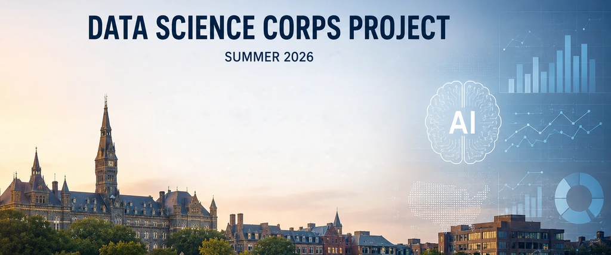

# AI Adoption and Job-Market Demand: Time-Series Analysis

- Show All Code
- Hide All Code
- View Source

Data analytics, software, and overall U.S. job openings versus Google Trends, technology stocks, CAPEX, PPI, and macroeconomic indicators

Author

Dr. Purna Gamage

Published

November 12, 2026

# 1 Introduction

The rapid growth of generative AI raises important questions about how AI adoption is reflected in labor-market demand, especially for data analytics and software roles. This analysis examines whether public interest, technology market signals, technology investment, and macroeconomic indicators help explain and forecast changes in job openings.

**Research questions**

1. How do data analytics (DA) and software (SW) job openings differ from overall U.S. job openings (ALL) in their relationship with macroeconomic and technology investment indicators?
2. Can public interest and technology investment signals help predict changes in job-market demand for AI- and data-related roles?

**Data**

| Variable(s) | Description | Source |
| --- | --- | --- |
| DA, SW, ALL job openings | Daily job-posting indices | Indeed Hiring Lab |
| Google Trends | Search interest in AI-related job titles and skills | Google Trends |
| MSFT, C3AI, NVDA, GOOGL | Adjusted closing stock prices | Yahoo Finance |
| CAPEX, PPI (Information) | Capital expenditure and producer price index (daily-interpolated) | FRED |
| FEDFUNDS, PCE, PPI (Information) | Monthly macroeconomic indicators | FRED |

**Workflow**

- **Part 1 – Exploratory analysis (daily):** time-series plots, linear regression, and cross-correlation (CCF) in levels and first differences.
- **Part 2 – Forecasting (daily):** baseline univariate ARIMA and Prophet models versus regression models with ARIMA errors (ARIMAX) using each group of external predictors; test-period accuracy comparison.
- **Part 3 – Macroeconomic ARIMAX (monthly):** a full Box–Jenkins workflow (EDA, stationarity, regression, SARIMA error modeling, parameter search, time-series cross-validation, diagnostics, final model, and forecasts) for DA job openings using the Federal Funds Rate, PCE, and PPI (Information).

# 2 Setup

```r
library(tidyverse)
library(lubridate)
library(forecast)
library(prophet)
library(patchwork)
library(broom)
library(scales)
library(knitr)
library(kableExtra)
library(tseries)
library(astsa)
library(plotly)
library(gridExtra)

# ------------------------------------------------------------
# Paths (relative to this .qmd file; keep the folder structure)
#   data/daily/    job openings, Google Trends, stocks, CAPEX, PPI
#   data/monthly/  FEDFUNDS, PCE, PPI (Information), DA job postings
# ------------------------------------------------------------

data_folder         <- file.path("data", "daily")
monthly_data_folder <- file.path("data", "monthly")

# Where figures and CSV results are saved
output_folder <- "outputs"
save_outputs  <- TRUE

dir.create(output_folder, showWarnings = FALSE, recursive = TRUE)

# ------------------------------------------------------------
# Analysis settings
# ------------------------------------------------------------

lag_max          <- 30   # maximum CCF lag (days)
test_horizon     <- 36   # final observations held out for testing (days)
forecast_horizon <- 36   # future forecast horizon (days)

# ------------------------------------------------------------
# Speed settings
# ------------------------------------------------------------

# FALSE = fast stepwise auto.arima search (seconds per model).
# TRUE  = exhaustive search (no stepwise, no approximation); much slower
#         on ~1,800 daily observations (minutes per model).
exhaustive_search <- FALSE

# TRUE = reuse fitted models saved by a previous render (outputs/model_cache).
# Set to FALSE, or delete that folder, after changing the data or settings.
reuse_saved_models <- TRUE

# ------------------------------------------------------------
# Shared labels, colors, and plot theme
# ------------------------------------------------------------

job_labels <- c(
  DA  = "DA Job Openings",
  SW  = "SW Job Openings",
  ALL = "All Job Openings"
)

job_levels <- c("All Job Openings", "DA Job Openings", "SW Job Openings")

col_actual <- "#1F5A94"
col_pred   <- "#B2182B"

theme_ts <- function(base_size = 12) {
  theme_minimal(base_size = base_size) +
    theme(
      plot.title       = element_text(face = "bold", size = 17),
      plot.subtitle    = element_text(size = 11, color = "gray35"),
      strip.text       = element_text(face = "bold", size = 10),
      panel.grid.minor = element_blank(),
      legend.position  = "bottom",
      plot.caption     = element_text(hjust = 0, face = "italic", color = "gray40")
    )
}

save_plot <- function(plot, file_name, width = 13, height = 9) {
  if (save_outputs) {
    ggsave(
      filename = file.path(output_folder, file_name),
      plot = plot, width = width, height = height, dpi = 300, bg = "white"
    )
  }
}

# Fit once, then reload the saved result on later renders
cache_folder <- file.path(output_folder, "model_cache")
dir.create(cache_folder, showWarnings = FALSE, recursive = TRUE)

cached <- function(name, expr) {
  file <- file.path(cache_folder, paste0(name, ".rds"))
  if (reuse_saved_models && file.exists(file)) {
    message("Loaded saved results: ", file)
    return(readRDS(file))
  }
  value <- expr
  saveRDS(value, file)
  value
}

save_table <- function(data, file_name) {
  if (save_outputs) {
    write_csv(data, file.path(output_folder, file_name))
  }
}
```

# 3 Data Preparation (Daily)

## 3.1 Load and merge all sources

Each file is read, its date column is detected and parsed, and every other column is prefixed with the file name so that variables remain identifiable after merging. The datasets are then restricted to their common overlapping period.

```r
files <- c(
  "AI_historical_data.csv",
  "GOOGL_historical_data.csv",
  "MSFT_historical_data.csv",
  "NVDA_historical_data.csv",
  "all_capex_ppi_daily_interpolated.csv",
  "GT_jobs_int.csv",
  "GT_skills_int.csv",
  "indeed_data_analysis.csv",
  "indeed-all.csv",
  "indeed-software.csv"
)

read_file <- function(filename) {

  data <- read_csv(file.path(data_folder, filename), show_col_types = FALSE)

  # Find the date column
  date_col <- names(data)[grepl("date|month|time", names(data), ignore.case = TRUE)][1]

  if (is.na(date_col)) {
    stop("No date column found in: ", filename)
  }

  # Parse dates in any of the common formats
  date_values <- as.character(data[[date_col]])

  parsed_dates <- suppressWarnings(
    as.Date(
      parse_date_time(
        date_values,
        orders = c("ymd", "mdy", "dmy", "ym", "my", "Ymd", "bY", "BY",
                   "bdy", "Ymd HMS", "ymd HMS")
      )
    )
  )

  if (all(is.na(parsed_dates))) {
    stop("Dates could not be read in: ", filename,
         "\nFirst date values: ", paste(head(date_values), collapse = ", "))
  }

  names(data)[names(data) == date_col] <- "Date"
  data$Date <- parsed_dates

  # Prefix all other columns with the file name
  file_prefix <- make.names(tools::file_path_sans_ext(filename))

  data %>%
    filter(!is.na(Date)) %>%
    rename_with(~ paste0(file_prefix, "_", .x), -Date)
}

data_list <- lapply(files, read_file)

# Common overlapping period
common_start <- max(do.call(c, lapply(data_list, function(x) min(x$Date))))
common_end   <- min(do.call(c, lapply(data_list, function(x) max(x$Date))))

combined_data <- reduce(data_list, full_join, by = "Date") %>%
  filter(Date >= common_start, Date <= common_end) %>%
  arrange(Date)

tibble(
  Start        = common_start,
  End          = common_end,
  Rows         = nrow(combined_data),
  Columns      = ncol(combined_data)
) %>%
  kable(caption = "Common study period") %>%
  kable_styling(full_width = FALSE)
```

Common study period

| Start | End | Rows | Columns |
| --- | --- | --- | --- |
| 2020-12-09 | 2026-01-01 | 1850 | 34 |

## 3.2 Select the analysis variables

```r
get_numeric_columns <- function(pattern) {
  columns <- grep(pattern, names(combined_data), value = TRUE, ignore.case = TRUE)
  columns[vapply(columns, function(x) is.numeric(combined_data[[x]]), logical(1))]
}

get_job_column <- function(pattern) {
  columns <- get_numeric_columns(pattern)
  if (length(columns) == 0) return(NA_character_)
  preferred <- columns[grepl("main[._]?value|job.*opening|posting.*index|value",
                             columns, ignore.case = TRUE)]
  if (length(preferred) > 0) preferred[1] else columns[1]
}

get_stock_column <- function(pattern) {
  columns <- get_numeric_columns(pattern)
  if (length(columns) == 0) return(NA_character_)
  # Prefer adjusted close, otherwise close
  preferred <- columns[grepl("adj.*close|adjusted.*close", columns, ignore.case = TRUE)]
  if (length(preferred) == 0) {
    preferred <- columns[grepl("close", columns, ignore.case = TRUE)]
  }
  if (length(preferred) > 0) preferred[1] else columns[1]
}

# 1. Job-opening series (outcomes)
job_columns <- c(
  DA  = get_job_column("^indeed_data_analysis_"),
  SW  = get_job_column("^indeed[.]software_"),
  ALL = get_job_column("^indeed[.]all_")
)

# 2. Google Trends (job titles and skills)
gt_jobs_columns   <- get_numeric_columns("^GT_jobs_int_")
gt_skills_columns <- get_numeric_columns("^GT_skills_int_")

google_columns <- c(gt_jobs_columns, gt_skills_columns)
names(google_columns) <- c(
  paste0("GT Job: ",   sub("^GT_jobs_int_",   "", gt_jobs_columns)),
  paste0("GT Skill: ", sub("^GT_skills_int_", "", gt_skills_columns))
)

# 3. Technology stock prices
stock_columns <- c(
  MSFT  = get_stock_column("^MSFT_historical_data_"),
  C3AI  = get_stock_column("^AI_historical_data_"),
  NVDA  = get_stock_column("^NVDA_historical_data_"),
  GOOGL = get_stock_column("^GOOGL_historical_data_")
)

# 4. CAPEX and PPI
capex_ppi_columns <- get_numeric_columns("^all_capex_ppi_daily_interpolated_")
names(capex_ppi_columns) <- sub("^all_capex_ppi_daily_interpolated_", "", capex_ppi_columns)

# All predictors and their groups
predictor_columns <- c(google_columns, stock_columns, capex_ppi_columns)

predictor_groups <- setNames(
  c(rep("Google Trends", length(google_columns)),
    rep("Stock Prices",  length(stock_columns)),
    rep("CAPEX and PPI", length(capex_ppi_columns))),
  names(predictor_columns)
)

if (any(is.na(job_columns)))       stop("One or more job-opening columns could not be identified.")
if (any(is.na(predictor_columns))) stop("One or more predictor columns could not be identified.")

tibble(
  Group  = c(rep("Job Openings", length(job_columns)), unname(predictor_groups)),
  Series = c(names(job_columns), names(predictor_columns)),
  Column = c(unname(job_columns), unname(predictor_columns))
) %>%
  kable(caption = "Variables used in the daily analysis") %>%
  kable_styling(full_width = FALSE, bootstrap_options = c("striped", "condensed"))
```

Variables used in the daily analysis

| Group | Series | Column |
| --- | --- | --- |
| Job Openings | DA | indeed_data_analysis_value |
| Job Openings | SW | indeed.software_IHLIDXUSTPSOFTDEVE |
| Job Openings | ALL | indeed.all_IHLIDXUS |
| Google Trends | GT Job: GT_jobs | GT_jobs_int_GT_jobs |
| Google Trends | GT Skill: GT_skills | GT_skills_int_GT_skills |
| Stock Prices | MSFT | MSFT_historical_data_Close |
| Stock Prices | C3AI | AI_historical_data_Close |
| Stock Prices | NVDA | NVDA_historical_data_Close |
| Stock Prices | GOOGL | GOOGL_historical_data_Close |
| CAPEX and PPI | PCUAINFOAINFO | all_capex_ppi_daily_interpolated_PCUAINFOAINFO |
| CAPEX and PPI | capex | all_capex_ppi_daily_interpolated_capex |

## 3.3 Build a regularly spaced daily dataset

Stock prices are only observed on trading days, so the merged data are placed on a complete daily calendar (duplicate dates are averaged). Two versions are created:

- `ccf_data`: only *internal* gaps are linearly interpolated (used for CCF).
- `model_data`: all gaps are filled with `forecast::na.interp()` (used for regression and forecasting models).

```r
needed_columns <- unique(c("Date", unname(job_columns), unname(predictor_columns)))

daily_data <- combined_data %>%
  select(all_of(needed_columns)) %>%
  group_by(Date) %>%
  summarise(
    across(everything(), ~ if (all(is.na(.x))) NA_real_ else mean(.x, na.rm = TRUE)),
    .groups = "drop"
  ) %>%
  complete(Date = seq(min(Date), max(Date), by = "day")) %>%
  arrange(Date)

# Interpolate internal gaps only (no extrapolation at the ends)
interpolate_daily <- function(x, dates) {
  available <- !is.na(x)
  if (sum(available) < 2) return(x)
  approx(
    x = as.numeric(dates[available]), y = x[available],
    xout = as.numeric(dates), rule = 1
  )$y
}

ccf_data <- daily_data %>%
  mutate(across(-Date, ~ interpolate_daily(.x, Date)))

model_data <- daily_data %>%
  mutate(across(-Date, ~ as.numeric(forecast::na.interp(.x))))

tibble(
  Dataset = c("ccf_data", "model_data"),
  Days    = c(nrow(ccf_data), nrow(model_data)),
  Missing_values = c(sum(is.na(ccf_data[-1])), sum(is.na(model_data[-1])))
) %>%
  kable(caption = "Daily datasets") %>%
  kable_styling(full_width = FALSE)
```

Daily datasets

| Dataset | Days | Missing_values |
| --- | --- | --- |
| ccf_data | 1850 | 4 |
| model_data | 1850 | 0 |

# 4 Part 1 – Exploratory Analysis

## 4.1 Time-series plots

Each figure places the three job-opening series above one group of external predictors on a shared time axis. Every panel has its own vertical scale.

```r
clean_gt_label <- function(x) {
  x %>%
    str_replace("^GT Job: ", "Job title: ") %>%
    str_replace("^GT Skill: ", "Skill: ") %>%
    str_replace_all("[_.]", " ")
}

job_lookup <- tibble(
  Column = unname(job_columns),
  Series = c(DA  = "Data Analysis Job Openings",
             SW  = "Software Development Job Openings",
             ALL = "All Job Openings")[names(job_columns)]
)

plot_jobs_with <- function(pred_lookup, pred_title, pred_subtitle,
                           pred_color, figure_title) {

  lookup <- bind_rows(
    job_lookup  %>% mutate(Group = "Job Openings"),
    pred_lookup %>% mutate(Group = "Predictors")
  )

  long_data <- daily_data %>%
    select(Date, all_of(lookup$Column)) %>%
    pivot_longer(-Date, names_to = "Column", values_to = "Value") %>%
    left_join(lookup, by = "Column") %>%
    filter(!is.na(Value)) %>%
    mutate(Series = factor(Series, levels = unique(lookup$Series)))

  date_limits <- range(long_data$Date)

  make_panel <- function(group, color, title, subtitle, show_x) {
    long_data %>%
      filter(Group == group) %>%
      ggplot(aes(Date, Value)) +
      geom_line(linewidth = 0.7, color = color) +
      facet_grid(Series ~ ., scales = "free_y", switch = "y") +
      scale_x_date(limits = date_limits, date_breaks = "6 months",
                   date_labels = "%b %Y", expand = expansion(mult = 0.01)) +
      labs(title = title, subtitle = subtitle,
           x = if (show_x) "Date" else NULL, y = NULL) +
      theme_ts() +
      theme(
        strip.placement   = "outside",
        strip.background  = element_blank(),
        strip.text.y.left = element_text(angle = 0, hjust = 1, face = "bold", size = 9),
        axis.text.x       = if (show_x) element_text(angle = 45, hjust = 1) else element_blank(),
        axis.ticks.x      = if (show_x) element_line() else element_blank()
      )
  }

  top <- make_panel("Job Openings", col_actual, "Job Openings",
                    "Daily posting indices for data analysis, software, and all jobs",
                    show_x = FALSE)

  bottom <- make_panel("Predictors", pred_color, pred_title, pred_subtitle,
                       show_x = TRUE)

  (top / bottom) +
    plot_layout(heights = c(3, nrow(pred_lookup))) +
    plot_annotation(
      title = figure_title,
      subtitle = "Each panel uses its own vertical scale; all panels share the same time axis",
      theme = theme(plot.title = element_text(face = "bold", size = 20),
                    plot.subtitle = element_text(size = 12, color = "gray35"))
    )
}
```

### 4.1.1 Job openings and Google search interest

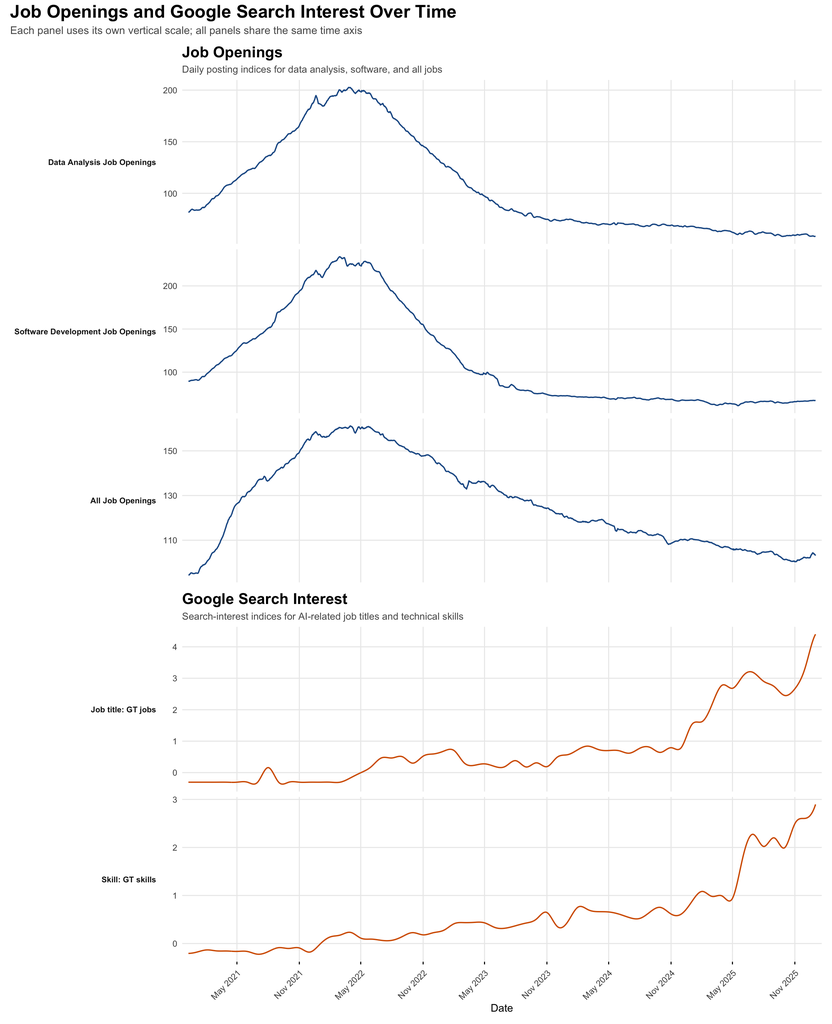

```r
google_lookup <- tibble(
  Column = unname(google_columns),
  Series = clean_gt_label(names(google_columns))
)

fig_jo_google <- plot_jobs_with(
  google_lookup,
  pred_title    = "Google Search Interest",
  pred_subtitle = "Search-interest indices for AI-related job titles and technical skills",
  pred_color    = "#D55E00",
  figure_title  = "Job Openings and Google Search Interest Over Time"
)

fig_jo_google
```

```r
save_plot(fig_jo_google, "EDA_Job_Openings_vs_Google_Trends.png", height = 16)
```

### 4.1.2 Job openings and technology stock prices

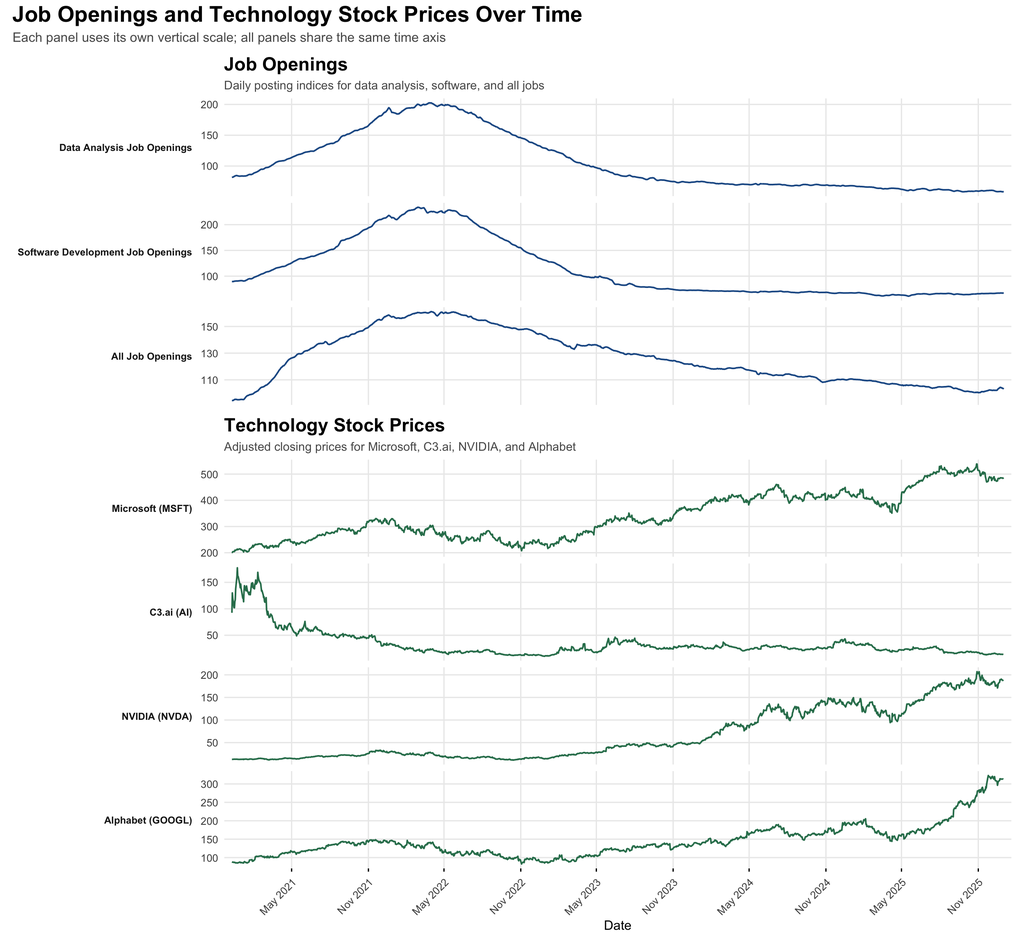

```r
stock_lookup <- tibble(
  Column = unname(stock_columns),
  Series = c(MSFT = "Microsoft (MSFT)", C3AI = "C3.ai (AI)",
             NVDA = "NVIDIA (NVDA)",    GOOGL = "Alphabet (GOOGL)")[names(stock_columns)]
)

fig_jo_stocks <- plot_jobs_with(
  stock_lookup,
  pred_title    = "Technology Stock Prices",
  pred_subtitle = "Adjusted closing prices for Microsoft, C3.ai, NVIDIA, and Alphabet",
  pred_color    = "#2E7D5B",
  figure_title  = "Job Openings and Technology Stock Prices Over Time"
)

fig_jo_stocks
```

```r
save_plot(fig_jo_stocks, "EDA_Job_Openings_vs_Stocks.png", height = 12)
```

### 4.1.3 Job openings and economic indicators (CAPEX and PPI)

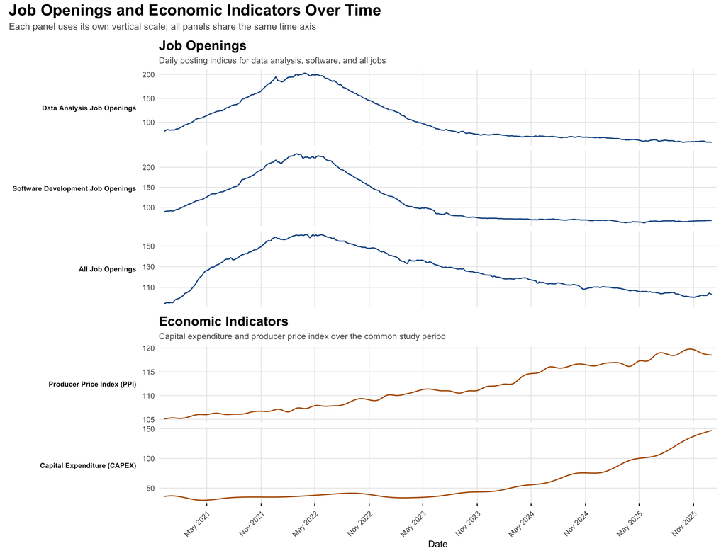

```r
economic_lookup <- tibble(
  Column = unname(capex_ppi_columns),
  Series = case_when(
    grepl("capex",   names(capex_ppi_columns), ignore.case = TRUE) ~ "Capital Expenditure (CAPEX)",
    grepl("PCU|PPI", names(capex_ppi_columns), ignore.case = TRUE) ~ "Producer Price Index (PPI)",
    TRUE ~ names(capex_ppi_columns)
  )
)

fig_jo_econ <- plot_jobs_with(
  economic_lookup,
  pred_title    = "Economic Indicators",
  pred_subtitle = "Capital expenditure and producer price index over the common study period",
  pred_color    = "#B45F06",
  figure_title  = "Job Openings and Economic Indicators Over Time"
)

fig_jo_econ
```

```r
save_plot(fig_jo_econ, "EDA_Job_Openings_vs_CAPEX_PPI.png", height = 10)
```

## 4.2 Linear regression

As a first look at explanatory power, each job-opening series is regressed on each predictor group separately (contemporaneous values, no time-series error structure). Because these are trending series, the R² values describe co-movement and should not be read as causal effects; residual autocorrelation is addressed in Parts 2 and 3.

```r
fit_models <- function(predictors) {
  lapply(job_columns, function(outcome) {
    model_formula <- as.formula(
      paste0("`", outcome, "` ~ ", paste0("`", unname(predictors), "`", collapse = " + "))
    )
    lm(model_formula, data = model_data)
  })
}

regression_models <- list(
  "Google Trends" = fit_models(google_columns),
  "Stock Prices"  = fit_models(stock_columns),
  "CAPEX and PPI" = fit_models(capex_ppi_columns)
)

regression_results <- imap_dfr(regression_models, function(models, group) {
  imap_dfr(models, function(model, job) {
    fit <- glance(model)
    tibble(
      Predictor_Group = group,
      Job_Openings    = job_labels[[job]],
      R_Squared       = fit$r.squared,
      Adj_R_Squared   = fit$adj.r.squared,
      RMSE            = sqrt(mean(residuals(model)^2)),
      AIC             = fit$AIC,
      N               = nobs(model)
    )
  })
})

save_table(regression_results, "Regression_Model_Summary.csv")

regression_results %>%
  kable(digits = 3, caption = "Linear regression of job openings on each predictor group") %>%
  kable_styling(full_width = FALSE, bootstrap_options = c("striped", "hover", "condensed")) %>%
  collapse_rows(columns = 1, valign = "top")
```

Linear regression of job openings on each predictor group

| Predictor_Group | Job_Openings | R_Squared | Adj_R_Squared | RMSE | AIC | N |
| --- | --- | --- | --- | --- | --- | --- |
| Google Trends | DA Job Openings | 0.372 | 0.371 | 36.578 | 18576.07 | 1850 |
|  | SW Job Openings | 0.338 | 0.337 | 45.144 | 19354.58 | 1850 |
|  | All Job Openings | 0.370 | 0.369 | 15.425 | 15381.17 | 1850 |
| Stock Prices | DA Job Openings | 0.656 | 0.655 | 27.079 | 17467.53 | 1850 |
|  | SW Job Openings | 0.610 | 0.609 | 34.668 | 18381.61 | 1850 |
|  | All Job Openings | 0.826 | 0.826 | 8.101 | 13002.37 | 1850 |
| CAPEX and PPI | DA Job Openings | 0.570 | 0.569 | 30.262 | 17874.64 | 1850 |
|  | SW Job Openings | 0.572 | 0.571 | 36.316 | 18549.45 | 1850 |
|  | All Job Openings | 0.470 | 0.470 | 14.141 | 15059.73 | 1850 |

**NoteFull regression summaries**

```r
for (group in names(regression_models)) {
  for (job in names(regression_models[[group]])) {
    cat("\n==========", group, "->", job_labels[[job]], "==========\n")
    print(summary(regression_models[[group]][[job]]))
  }
}
```

```
========== Google Trends -> DA Job Openings ==========

Call:
lm(formula = model_formula, data = model_data)

Residuals:
   Min     1Q Median     3Q    Max
-53.66 -32.50 -13.31  25.43  80.40

Coefficients:
                        Estimate Std. Error t value Pr(>|t|)
(Intercept)              127.110      1.081 117.541  < 2e-16 ***
GT_jobs_int_GT_jobs       -8.134      2.182  -3.728 0.000198 ***
GT_skills_int_GT_skills  -27.287      3.282  -8.314  < 2e-16 ***
---
Signif. codes:  0 '***' 0.001 '**' 0.01 '*' 0.05 '.' 0.1 ' ' 1

Residual standard error: 36.61 on 1847 degrees of freedom
Multiple R-squared:  0.3717,    Adjusted R-squared:  0.371
F-statistic: 546.3 on 2 and 1847 DF,  p-value: < 2.2e-16


========== Google Trends -> SW Job Openings ==========

Call:
lm(formula = model_formula, data = model_data)

Residuals:
   Min     1Q Median     3Q    Max
-57.55 -40.88 -16.60  29.52  98.16

Coefficients:
                        Estimate Std. Error t value Pr(>|t|)
(Intercept)              137.744      1.335 103.205  < 2e-16 ***
GT_jobs_int_GT_jobs      -10.981      2.693  -4.078 4.73e-05 ***
GT_skills_int_GT_skills  -28.862      4.051  -7.125 1.48e-12 ***
---
Signif. codes:  0 '***' 0.001 '**' 0.01 '*' 0.05 '.' 0.1 ' ' 1

Residual standard error: 45.18 on 1847 degrees of freedom
```

[output cut: 159 more lines]

```
Coefficients:
                                                Estimate Std. Error t value
(Intercept)                                    324.96146   15.88698  20.455
all_capex_ppi_daily_interpolated_PCUAINFOAINFO  -1.67400    0.15220 -10.999
all_capex_ppi_daily_interpolated_capex          -0.20134    0.02235  -9.007
                                               Pr(>|t|)
(Intercept)                                      <2e-16 ***
all_capex_ppi_daily_interpolated_PCUAINFOAINFO   <2e-16 ***
all_capex_ppi_daily_interpolated_capex           <2e-16 ***
---
Signif. codes:  0 '***' 0.001 '**' 0.01 '*' 0.05 '.' 0.1 ' ' 1

Residual standard error: 14.15 on 1847 degrees of freedom
Multiple R-squared:  0.4705,    Adjusted R-squared:  0.4699
F-statistic: 820.6 on 2 and 1847 DF,  p-value: < 2.2e-16
```

## 4.3 Cross-correlation analysis (CCF)

We use the CCF to examine lead–lag dependence between job openings and each external signal. The sample CCF at lag $k$ estimates $\text{cor}(\text{Job}_{t+k}, X_t)$, so:

- **positive lags** → the predictor *leads* job openings,
- **negative lags** → job openings lead the predictor,
- **lag 0** → same-day relationship.

Approximate 95% significance limits are $\pm 1.96/\sqrt{N}$.

**Important**

**CCF on raw levels can be misleading.** When two series are trending or nonstationary, they can appear strongly correlated at every lag simply because they share a trend. We therefore report the CCF on levels for completeness, and then on **first-differenced** series (daily changes), which is the more reliable basis for identifying lead–lag structure. Prewhitening is a further refinement.

```r
compute_ccf <- function(data, lag_max) {

  results <- list()

  for (job_name in names(job_columns)) {
    for (predictor_name in names(predictor_columns)) {

      pair <- data %>%
        select(job  = all_of(job_columns[[job_name]]),
               pred = all_of(predictor_columns[[predictor_name]])) %>%
        drop_na()

      if (nrow(pair) > lag_max + 2 && sd(pair$job) > 0 && sd(pair$pred) > 0) {

        cc <- ccf(pair$job, pair$pred, lag.max = lag_max, plot = FALSE)

        results[[length(results) + 1]] <- tibble(
          Category        = predictor_groups[[predictor_name]],
          Job_Openings    = job_name,
          Predictor       = predictor_name,
          Lag             = as.numeric(cc$lag),
          CCF             = as.numeric(cc$acf),
          N               = nrow(pair),
          Approx_95_Bound = 1.96 / sqrt(nrow(pair))
        )
      }
    }
  }

  bind_rows(results) %>%
    mutate(Significant = abs(CCF) > Approx_95_Bound)
}

label_ccf <- function(ccf_df) {
  ccf_df %>%
    mutate(
      Job_Type = factor(
        recode(Job_Openings, DA = "Data Analysis", SW = "Software Development",
               ALL = "All Job Openings"),
        levels = c("All Job Openings", "Data Analysis", "Software Development")
      ),
      Predictor_Label = case_when(
        Category == "Google Trends" ~ clean_gt_label(Predictor),
        Predictor == "MSFT"  ~ "Microsoft (MSFT)",
        Predictor == "C3AI"  ~ "C3.ai (AI)",
        Predictor == "NVDA"  ~ "NVIDIA (NVDA)",
        Predictor == "GOOGL" ~ "Alphabet (GOOGL)",
        grepl("PCU|PPI", Predictor, ignore.case = TRUE) ~ "PPI (Information)",
        grepl("CAPEX",   Predictor, ignore.case = TRUE) ~ "CAPEX",
        TRUE ~ Predictor
      ),
      Category = factor(Category, levels = c("Google Trends", "Stock Prices", "CAPEX and PPI"))
    )
}

# Strongest absolute CCF for each job x predictor pair
ccf_peaks <- function(ccf_df) {
  ccf_df %>%
    group_by(Category, Job_Type, Predictor_Label) %>%
    slice_max(abs(CCF), n = 1, with_ties = FALSE) %>%
    ungroup() %>%
    mutate(
      Lag_Interpretation = case_when(
        Lag > 0 ~ "Predictor leads job openings",
        Lag < 0 ~ "Job openings lead predictor",
        TRUE    ~ "Same-day relationship"
      )
    ) %>%
    arrange(Category, Job_Type, desc(abs(CCF))) %>%
    select(Category, Job_Type, Predictor = Predictor_Label, Lag, CCF,
           Approx_95_Bound, Significant, Lag_Interpretation)
}

# Heatmap of all CCF values
ccf_heatmap <- function(ccf_df, title, subtitle) {
  ggplot(ccf_df, aes(Lag, Predictor_Label, fill = CCF)) +
    geom_tile(color = "white", linewidth = 0.2) +
    geom_vline(xintercept = 0, color = "black", linewidth = 0.6) +
    facet_grid(Category ~ Job_Type, scales = "free_y", space = "free_y", switch = "y") +
    scale_fill_gradient2(low = "#3B4CC0", mid = "#F7F7F7", high = "#B40426",
                         midpoint = 0, limits = c(-1, 1), oob = squish,
                         breaks = seq(-1, 1, 0.5), name = "CCF") +
    scale_x_continuous(breaks = seq(-20, 20, 10), expand = c(0, 0)) +
    labs(title = title, subtitle = subtitle, x = "Lag in days", y = NULL,
         caption = paste0("Blue = negative, red = positive correlation. ",
                          "Positive lags indicate that the external indicator leads job openings.")) +
    theme_ts() +
    theme(panel.grid = element_blank(),
          strip.placement = "outside",
          strip.text.y.left = element_text(angle = 0, face = "bold"),
          axis.text.y = element_text(size = 8.5),
          legend.position = "right")
}

# Stem plots; significant lags are highlighted
ccf_stem_plot <- function(ccf_df, title, subtitle, facet = c("grid", "wrap")) {

  facet  <- match.arg(facet)
  bounds <- ccf_df %>% distinct(Job_Type, Predictor_Label, Approx_95_Bound)

  p <- ggplot(ccf_df, aes(Lag, CCF)) +
    geom_hline(yintercept = 0, linewidth = 0.4) +
    geom_hline(data = bounds, aes(yintercept =  Approx_95_Bound),
               linetype = "dashed", linewidth = 0.45, color = "steelblue") +
    geom_hline(data = bounds, aes(yintercept = -Approx_95_Bound),
               linetype = "dashed", linewidth = 0.45, color = "steelblue") +
    geom_segment(aes(xend = Lag, y = 0, yend = CCF, color = Significant), linewidth = 0.6) +
    geom_vline(xintercept = 0, linewidth = 0.5) +
    scale_color_manual(values = c(`TRUE` = "#3B4CC0", `FALSE` = "gray65"),
                       labels = c(`TRUE` = "Outside 95% limits", `FALSE` = "Within limits"),
                       name = NULL) +
    scale_x_continuous(breaks = seq(-lag_max, lag_max, 10)) +
    coord_cartesian(ylim = c(-1, 1)) +
    labs(title = title, subtitle = subtitle, x = "Lag in days",
         y = "Cross-correlation coefficient",
         caption = paste0("Dashed lines show approximate 95% limits. ",
                          "Positive lags indicate that the predictor leads job openings.")) +
    theme_ts()

  if (facet == "grid") {
    p + facet_grid(rows = vars(Job_Type), cols = vars(Predictor_Label))
  } else {
    p + facet_wrap(~ Predictor_Label, ncol = 3)
  }
}
```

### 4.3.1 CCF on levels

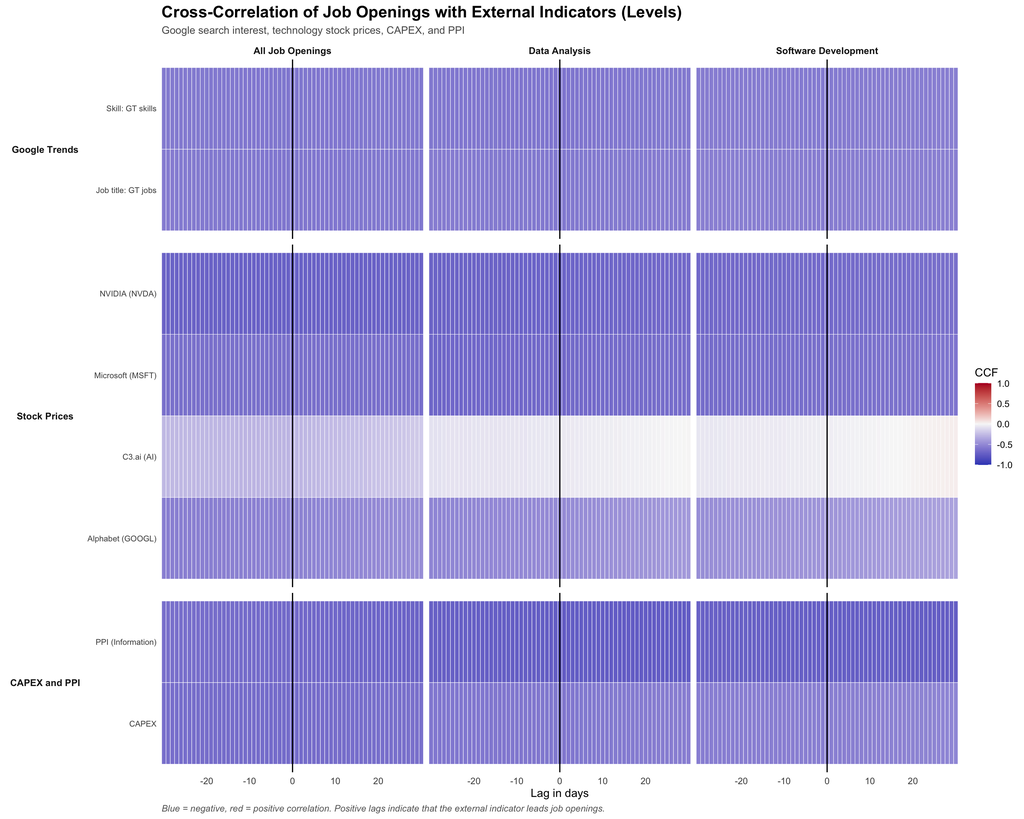

```r
ccf_levels <- compute_ccf(ccf_data, lag_max) %>% label_ccf()
save_table(ccf_levels, "CCF_levels_all_values.csv")

fig_ccf_levels_heat <- ccf_heatmap(
  ccf_levels,
  title    = "Cross-Correlation of Job Openings with External Indicators (Levels)",
  subtitle = "Google search interest, technology stock prices, CAPEX, and PPI"
)

fig_ccf_levels_heat
```

```r
save_plot(fig_ccf_levels_heat, "CCF_levels_heatmap.png", width = 15, height = 12)
```

The near-uniform colour across lags in the levels heatmap is the signature of shared trends rather than a genuine lead–lag relationship, which motivates differencing.

### 4.3.2 CCF on first differences

```r
ccf_data_diff <- ccf_data %>%
  arrange(Date) %>%
  mutate(across(-Date, ~ .x - dplyr::lag(.x))) %>%
  slice(-1)

ccf_diff <- compute_ccf(ccf_data_diff, lag_max) %>% label_ccf()
save_table(ccf_diff, "CCF_first_difference_all_values.csv")
```

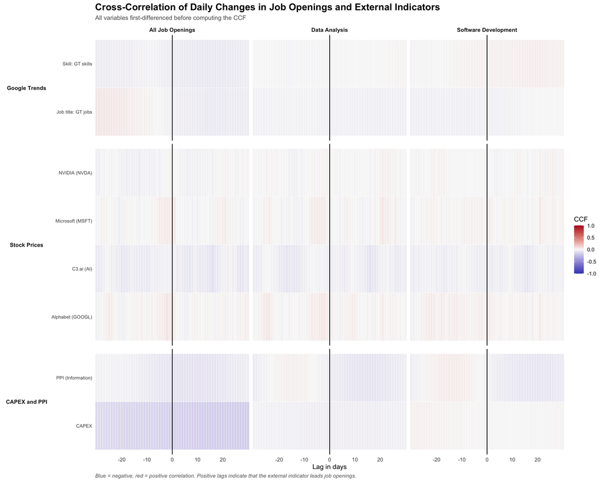

```r
fig_ccf_diff_heat <- ccf_heatmap(
  ccf_diff,
  title    = "Cross-Correlation of Daily Changes in Job Openings and External Indicators",
  subtitle = "All variables first-differenced before computing the CCF"
)

fig_ccf_diff_heat
```

```r
save_plot(fig_ccf_diff_heat, "CCF_first_difference_heatmap.png", width = 15, height = 12)
```

#### 4.3.2.1 Google Trends

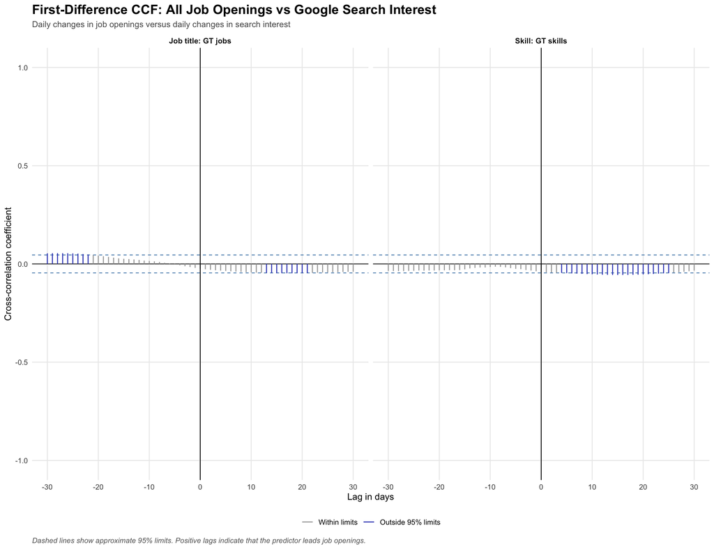

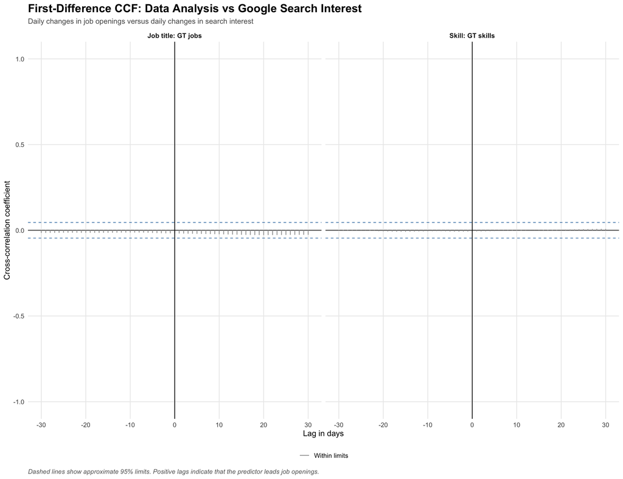

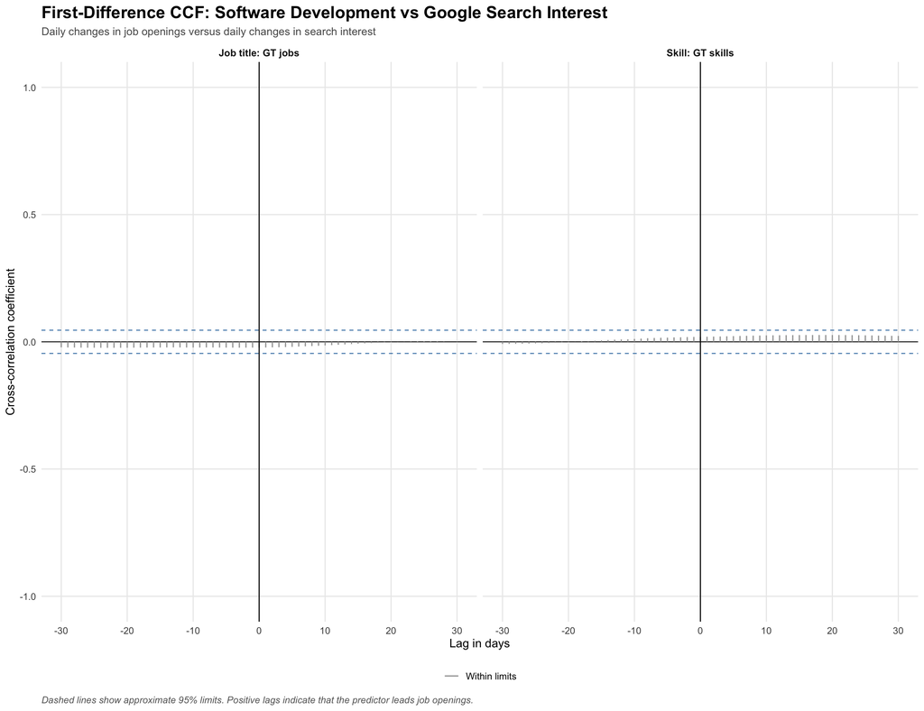

```r
for (job in levels(ccf_diff$Job_Type)) {

  p <- ccf_diff %>%
    filter(Category == "Google Trends", Job_Type == job) %>%
    ccf_stem_plot(
      title    = paste0("First-Difference CCF: ", job, " vs Google Search Interest"),
      subtitle = "Daily changes in job openings versus daily changes in search interest",
      facet    = "wrap"
    )

  print(p)
  save_plot(p, paste0("CCF_diff_", gsub("[^A-Za-z0-9]+", "_", job), "_vs_Google_Trends.png"))
}
```

#### 4.3.2.2 Technology stock prices

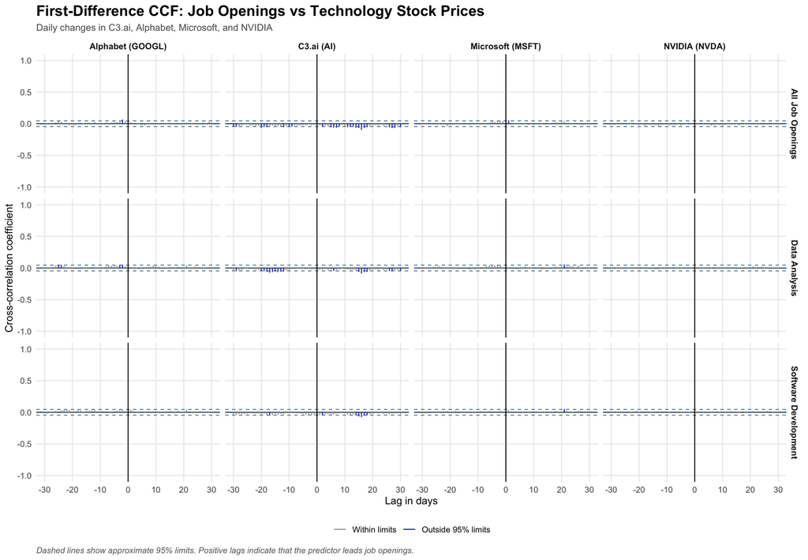

```r
fig_ccf_diff_stocks <- ccf_diff %>%
  filter(Category == "Stock Prices") %>%
  ccf_stem_plot(
    title    = "First-Difference CCF: Job Openings vs Technology Stock Prices",
    subtitle = "Daily changes in C3.ai, Alphabet, Microsoft, and NVIDIA"
  )

fig_ccf_diff_stocks
```

```r
save_plot(fig_ccf_diff_stocks, "CCF_diff_Job_Openings_vs_Stocks.png")
```

#### 4.3.2.3 CAPEX and PPI

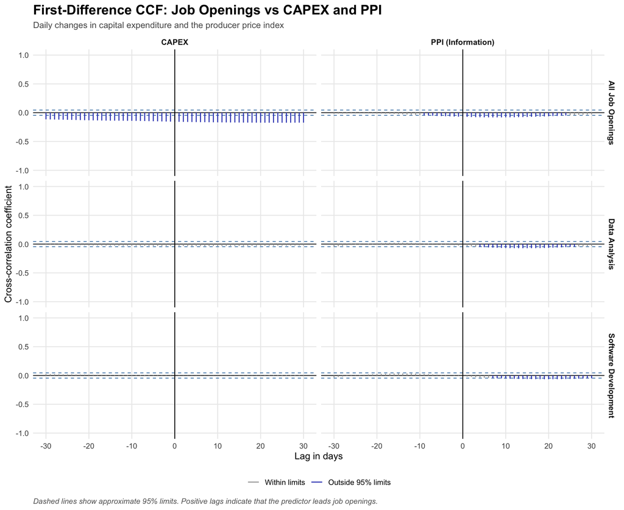

```r
fig_ccf_diff_capex <- ccf_diff %>%
  filter(Category == "CAPEX and PPI") %>%
  ccf_stem_plot(
    title    = "First-Difference CCF: Job Openings vs CAPEX and PPI",
    subtitle = "Daily changes in capital expenditure and the producer price index"
  )

fig_ccf_diff_capex
```

```r
save_plot(fig_ccf_diff_capex, "CCF_diff_Job_Openings_vs_CAPEX_PPI.png", width = 11)
```

#### 4.3.2.4 Strongest lead–lag relationships

```r
peak_levels <- ccf_peaks(ccf_levels)
peak_diff   <- ccf_peaks(ccf_diff)

save_table(peak_levels, "CCF_levels_peak_values.csv")
save_table(peak_diff,   "CCF_first_difference_peak_values.csv")

peak_diff %>%
  kable(digits = 3,
        caption = "Strongest first-difference CCF for each job-opening / predictor pair") %>%
  kable_styling(full_width = FALSE, bootstrap_options = c("striped", "hover", "condensed")) %>%
  collapse_rows(columns = 1:2, valign = "top") %>%
  scroll_box(height = "500px")
```

Strongest first-difference CCF for each job-opening / predictor pair

| Category | Job_Type | Predictor | Lag | CCF | Approx_95_Bound | Significant | Lag_Interpretation |
| --- | --- | --- | --- | --- | --- | --- | --- |
| Google Trends | All Job Openings | Skill: GT skills | 15 | -0.056 | 0.046 | TRUE | Predictor leads job openings |
|  |  | Job title: GT jobs | -28 | 0.055 | 0.046 | TRUE | Job openings lead predictor |
|  | Data Analysis | Job title: GT jobs | 20 | -0.028 | 0.046 | FALSE | Predictor leads job openings |
|  |  | Skill: GT skills | -15 | -0.009 | 0.046 | FALSE | Job openings lead predictor |
|  | Software Development | Skill: GT skills | 18 | 0.027 | 0.046 | FALSE | Predictor leads job openings |
|  |  | Job title: GT jobs | -23 | -0.024 | 0.046 | FALSE | Job openings lead predictor |
| Stock Prices | All Job Openings | C3.ai (AI) | 16 | -0.097 | 0.046 | TRUE | Predictor leads job openings |
|  |  | Alphabet (GOOGL) | -2 | 0.066 | 0.046 | TRUE | Job openings lead predictor |
|  |  | Microsoft (MSFT) | 1 | 0.053 | 0.046 | TRUE | Predictor leads job openings |
|  |  | NVIDIA (NVDA) | -13 | -0.037 | 0.046 | FALSE | Job openings lead predictor |
|  | Data Analysis | C3.ai (AI) | 16 | -0.086 | 0.046 | TRUE | Predictor leads job openings |
|  |  | Microsoft (MSFT) | 21 | 0.056 | 0.046 | TRUE | Predictor leads job openings |
|  |  | Alphabet (GOOGL) | -2 | 0.053 | 0.046 | TRUE | Job openings lead predictor |
|  |  | NVIDIA (NVDA) | 21 | 0.027 | 0.046 | FALSE | Predictor leads job openings |
|  | Software Development | C3.ai (AI) | 16 | -0.076 | 0.046 | TRUE | Predictor leads job openings |
|  |  | Microsoft (MSFT) | 21 | 0.052 | 0.046 | TRUE | Predictor leads job openings |
|  |  | Alphabet (GOOGL) | 1 | 0.043 | 0.046 | FALSE | Predictor leads job openings |
|  |  | NVIDIA (NVDA) | 26 | 0.025 | 0.046 | FALSE | Predictor leads job openings |
| CAPEX and PPI | All Job Openings | CAPEX | 24 | -0.174 | 0.046 | TRUE | Predictor leads job openings |
|  |  | PPI (Information) | 8 | -0.082 | 0.046 | TRUE | Predictor leads job openings |
|  | Data Analysis | PPI (Information) | 14 | -0.071 | 0.046 | TRUE | Predictor leads job openings |
|  |  | CAPEX | 10 | -0.033 | 0.046 | FALSE | Predictor leads job openings |
|  | Software Development | PPI (Information) | 20 | -0.065 | 0.046 | TRUE | Predictor leads job openings |
|  |  | CAPEX | -30 | 0.026 | 0.046 | FALSE | Job openings lead predictor |

# 5 Part 2 – Forecasting Job Openings (Daily)

## 5.1 Design

The final 36 days are held out as a test period. Every model is fitted on the training period only and then used to predict the test period.

| Model | Predictors | Purpose |
| --- | --- | --- |
| Univariate ARIMA (`auto.arima`) | None (own history) | Baseline |
| Prophet | None (trend + weekly/yearly seasonality) | Baseline |
| Regression + ARIMA errors | Technology stock prices | External signal |
| Regression + ARIMA errors | Google Trends | External signal |
| Regression + ARIMA errors | CAPEX + PPI | External signal |

Daily series are modelled with weekly seasonality (`frequency = 7`). The regression-with-ARIMA-error models use the **observed** predictor values in the test period (ex-post forecasts), so they measure how much the predictors explain out of sample rather than a fully operational forecast.

```r
# Fit on the training window and predict the test window.
# Returns the model plus fitted (training) and predicted (test) values.
fit_and_forecast <- function(y, xreg = NULL, h = test_horizon) {

  n         <- length(y)
  train_end <- n - h
  y_train   <- ts(y[1:train_end], frequency = 7)

  if (is.null(xreg)) {
    model <- auto.arima(y_train, seasonal = TRUE,
                        stepwise = !exhaustive_search, approximation = !exhaustive_search)
    fc <- forecast(model, h = h, level = 95)
  } else {
    xreg <- as.matrix(xreg)
    storage.mode(xreg) <- "double"
    model <- auto.arima(y_train, xreg = xreg[1:train_end, , drop = FALSE],
                        seasonal = TRUE, stepwise = !exhaustive_search, approximation = !exhaustive_search)
    fc <- forecast(model, xreg = xreg[(train_end + 1):n, , drop = FALSE], level = 95)
  }

  list(
    model = model,
    results = tibble(
      Actual           = y,
      Fitted_Predicted = c(as.numeric(fitted(model)), as.numeric(fc$mean)),
      Lower_95         = c(rep(NA_real_, train_end), as.numeric(fc$lower[, 1])),
      Upper_95         = c(rep(NA_real_, train_end), as.numeric(fc$upper[, 1])),
      Period           = rep(c("Training", "Test"), c(train_end, h))
    )
  )
}

# Actual vs predicted plot: test period only, or the whole series
plot_actual_vs_predicted <- function(pred_df, title, subtitle, whole = FALSE) {

  pred_name  <- if (whole) "Fitted / Predicted" else "Predicted"
  test_start <- min(pred_df$Date[pred_df$Period == "Test"])
  df         <- if (whole) pred_df else filter(pred_df, Period == "Test")

  long_df <- df %>%
    select(Date, Job_Type, Actual, Fitted_Predicted) %>%
    pivot_longer(c(Actual, Fitted_Predicted), names_to = "Series", values_to = "Value") %>%
    mutate(Series = if_else(Series == "Actual", "Actual", pred_name))

  p <- ggplot(df, aes(x = Date))

  if (!whole) {
    p <- p + geom_ribbon(aes(ymin = Lower_95, ymax = Upper_95),
                         fill = "gray70", alpha = 0.35)
  } else {
    p <- p + geom_vline(xintercept = test_start, color = "gray40",
                        linetype = "dotted", linewidth = 0.7)
  }

  p +
    geom_line(data = long_df, aes(y = Value, color = Series, linetype = Series),
              linewidth = if (whole) 0.6 else 0.9) +
    facet_grid(Job_Type ~ ., scales = "free_y") +
    scale_color_manual(values = setNames(c(col_actual, col_pred), c("Actual", pred_name))) +
    scale_linetype_manual(values = setNames(c("solid", "dashed"), c("Actual", pred_name))) +
    labs(
      title = title, subtitle = subtitle,
      x = "Date", y = "Job-posting index", color = NULL, linetype = NULL,
      caption = if (whole) {
        "Dashed line: fitted values (training) and predictions (test). Dotted vertical line marks the start of the test period."
      } else {
        paste0("The final ", test_horizon, " days were used as the test period. Shaded regions are 95% prediction intervals.")
      }
    ) +
    theme_ts()
}
```

## 5.2 Baseline models (job openings only)

### 5.2.1 Univariate ARIMA: future forecasts

Separate `auto.arima` models are fitted to the full history of each series to show the next 36 days.

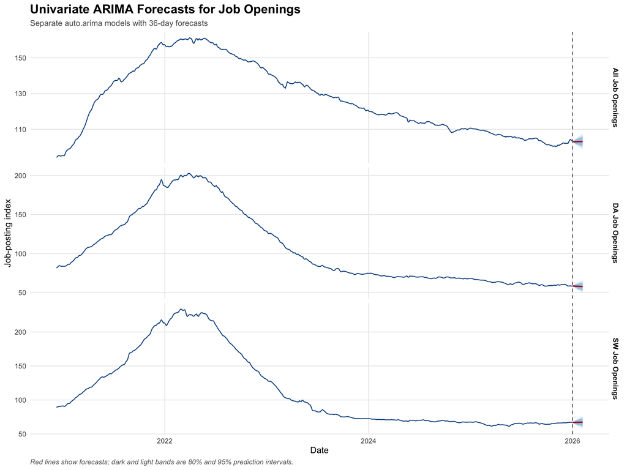

```r
arima_full_models <- cached("arima_full_models", lapply(job_columns, function(column_name) {
  auto.arima(ts(model_data[[column_name]], frequency = 7),
             seasonal = TRUE, stepwise = !exhaustive_search, approximation = !exhaustive_search)
}))

future_dates <- seq(max(model_data$Date) + 1, by = "day", length.out = forecast_horizon)

arima_future <- imap_dfr(arima_full_models, function(model, job) {
  fc <- forecast(model, h = forecast_horizon, level = c(80, 95))
  tibble(
    Date = future_dates, Forecast = as.numeric(fc$mean),
    Lower_80 = as.numeric(fc$lower[, "80%"]), Upper_80 = as.numeric(fc$upper[, "80%"]),
    Lower_95 = as.numeric(fc$lower[, "95%"]), Upper_95 = as.numeric(fc$upper[, "95%"]),
    Job_Type = job_labels[[job]]
  )
}) %>%
  mutate(Job_Type = factor(Job_Type, levels = job_levels))

arima_history <- imap_dfr(job_columns, function(column_name, job) {
  tibble(Date = model_data$Date, Value = model_data[[column_name]],
         Job_Type = job_labels[[job]])
}) %>%
  mutate(Job_Type = factor(Job_Type, levels = job_levels))

fig_arima_future <- ggplot() +
  geom_line(data = arima_history, aes(Date, Value), linewidth = 0.6, color = col_actual) +
  geom_ribbon(data = arima_future, aes(Date, ymin = Lower_95, ymax = Upper_95),
              fill = "#9ECAE1", alpha = 0.35) +
  geom_ribbon(data = arima_future, aes(Date, ymin = Lower_80, ymax = Upper_80),
              fill = "#4292C6", alpha = 0.40) +
  geom_line(data = arima_future, aes(Date, Forecast), linewidth = 0.9, color = col_pred) +
  geom_vline(xintercept = max(model_data$Date), linetype = "dashed", color = "gray35") +
  facet_grid(Job_Type ~ ., scales = "free_y") +
  labs(title = "Univariate ARIMA Forecasts for Job Openings",
       subtitle = paste0("Separate auto.arima models with ", forecast_horizon, "-day forecasts"),
       x = "Date", y = "Job-posting index",
       caption = "Red lines show forecasts; dark and light bands are 80% and 95% prediction intervals.") +
  theme_ts()

fig_arima_future
```

```r
save_plot(fig_arima_future, "ARIMA_future_forecasts.png", width = 12)

arima_full_models
```

```
$DA
Series: ts(model_data[[column_name]], frequency = 7)
ARIMA(0,2,1)(1,0,2)[7]

Coefficients:
          ma1     sar1    sma1     sma2
      -0.3954  -0.9223  0.0093  -0.8259
s.e.   0.0220   0.3248  0.3430   0.3139

sigma^2 = 0.01951:  log likelihood = 1011.48
AIC=-2012.95   AICc=-2012.92   BIC=-1985.34

$SW
Series: ts(model_data[[column_name]], frequency = 7)
ARIMA(0,2,2)(1,0,2)[7]

Coefficients:
          ma1     ma2     sar1     sma1     sma2
      -0.3765  0.0538  -0.9012  -0.0321  -0.8066
s.e.   0.0233  0.0223   0.1454   0.1565   0.1453

sigma^2 = 0.02162:  log likelihood = 916.93
AIC=-1821.86   AICc=-1821.81   BIC=-1788.72

$ALL
Series: ts(model_data[[column_name]], frequency = 7)
ARIMA(1,2,1)(0,0,1)[7]

Coefficients:
         ar1      ma1     sma1
      0.1721  -0.5675  -0.9037
s.e.  0.0518   0.0432   0.0104

sigma^2 = 0.006823:  log likelihood = 1982.97
AIC=-3957.94   AICc=-3957.92   BIC=-3935.85
```

### 5.2.2 Fit all test-period models

```r
predictor_sets <- list(
  "ARIMA (baseline)"       = NULL,
  "ARIMAX: Stock Prices"   = stock_columns,
  "ARIMAX: Google Trends"  = google_columns,
  "ARIMAX: CAPEX + PPI"    = capex_ppi_columns
)

forecast_runs <- cached("forecast_runs", local({

forecast_runs <- list()

for (set_name in names(predictor_sets)) {

  forecast_runs[[set_name]] <- list()
  xcols <- predictor_sets[[set_name]]

  for (job_name in names(job_columns)) {

    run <- fit_and_forecast(
      y    = model_data[[job_columns[[job_name]]]],
      xreg = if (is.null(xcols)) NULL else model_data[, unname(xcols)]
    )

    run$results <- run$results %>%
      mutate(Date = model_data$Date, Model = set_name,
             Job_Type = job_labels[[job_name]], .before = 1)

    forecast_runs[[set_name]][[job_name]] <- run
  }
}

forecast_runs
}))

# ------------------------------------------------------------
# Prophet baseline (training data only)
# ------------------------------------------------------------

prophet_results <- cached("prophet_results", local({

prophet_results <- list()

for (job_name in names(job_columns)) {

  series_data <- tibble(ds = model_data$Date,
                        y  = model_data[[job_columns[[job_name]]]])

  train_end  <- nrow(series_data) - test_horizon
  train_data <- series_data[1:train_end, ]

  model <- prophet(train_data,
                   daily.seasonality = FALSE, weekly.seasonality = TRUE,
                   yearly.seasonality = TRUE, interval.width = 0.95)

  pred <- predict(model, series_data %>% select(ds))

  prophet_results[[job_name]] <- tibble(
    Date             = series_data$ds,
    Model            = "Prophet (baseline)",
    Job_Type         = job_labels[[job_name]],
    Actual           = series_data$y,
    Fitted_Predicted = pred$yhat,
    Lower_95         = if_else(seq_len(nrow(series_data)) > train_end, pred$yhat_lower, NA_real_),
    Upper_95         = if_else(seq_len(nrow(series_data)) > train_end, pred$yhat_upper, NA_real_),
    Period           = rep(c("Training", "Test"), c(train_end, test_horizon))
  )
}

prophet_results
}))

# ------------------------------------------------------------
# All predictions in one table
# ------------------------------------------------------------

model_order <- c("ARIMA (baseline)", "Prophet (baseline)", "ARIMAX: Stock Prices",
                 "ARIMAX: Google Trends", "ARIMAX: CAPEX + PPI")

all_predictions <- bind_rows(
  map_dfr(forecast_runs, ~ map_dfr(.x, "results")),
  bind_rows(prophet_results)
) %>%
  mutate(Job_Type = factor(Job_Type, levels = job_levels),
         Model    = factor(Model, levels = model_order))

save_table(all_predictions, "All_model_predictions.csv")

get_predictions <- function(model_name) filter(all_predictions, Model == model_name)
```

### 5.2.3 Univariate ARIMA: actual vs predicted

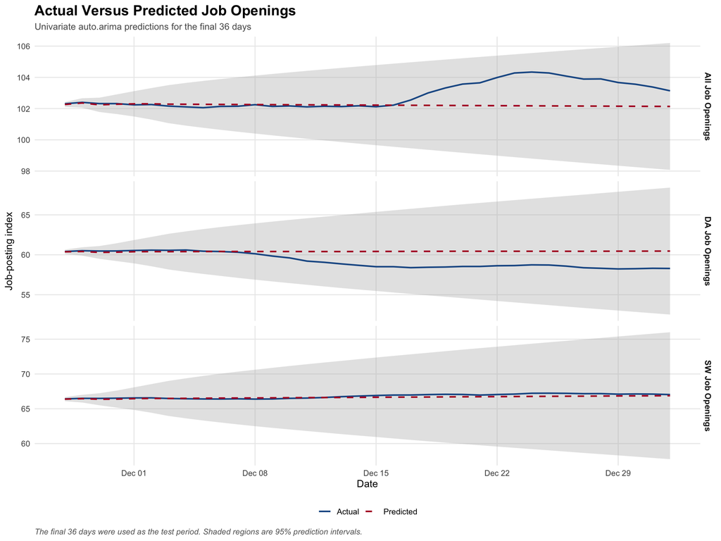

```r
fig <- plot_actual_vs_predicted(
  get_predictions("ARIMA (baseline)"),
  title = "Actual Versus Predicted Job Openings",
  subtitle = paste0("Univariate auto.arima predictions for the final ", test_horizon, " days")
)
fig
```

```r
save_plot(fig, "ARIMA_baseline_actual_vs_predicted.png", width = 12)
```

### 5.2.4 Prophet: actual vs predicted

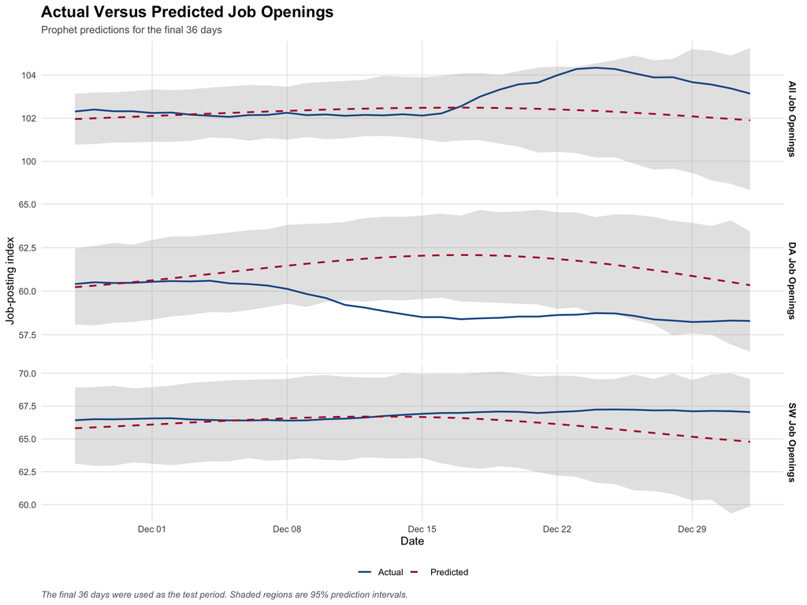

```r
fig <- plot_actual_vs_predicted(
  get_predictions("Prophet (baseline)"),
  title = "Actual Versus Predicted Job Openings",
  subtitle = paste0("Prophet predictions for the final ", test_horizon, " days")
)
fig
```

```r
save_plot(fig, "Prophet_baseline_actual_vs_predicted.png", width = 12)
```

## 5.3 Regression with ARIMA errors (ARIMAX)

The model for each job-opening series is

$$y_t = \beta_0 + \boldsymbol{\beta}^\top \mathbf{x}_t + n_t, \qquad n_t \sim \text{(S)ARIMA}(p,d,q)(P,D,Q)_7,$$

where $\mathbf{x}_t$ is one group of external predictors and the ARIMA orders for the error process are chosen by `auto.arima`.

### 5.3.1 Job openings vs. technology stock prices

**Test period**

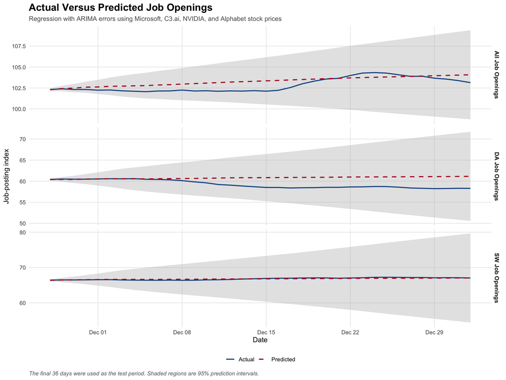

```r
fig <- plot_actual_vs_predicted(
  get_predictions("ARIMAX: Stock Prices"),
  title = "Actual Versus Predicted Job Openings",
  subtitle = "Regression with ARIMA errors using Microsoft, C3.ai, NVIDIA, and Alphabet stock prices"
)
fig
```

```r
save_plot(fig, "ARIMAX_Stocks_test_actual_vs_predicted.png", width = 12)
```

**Whole series**

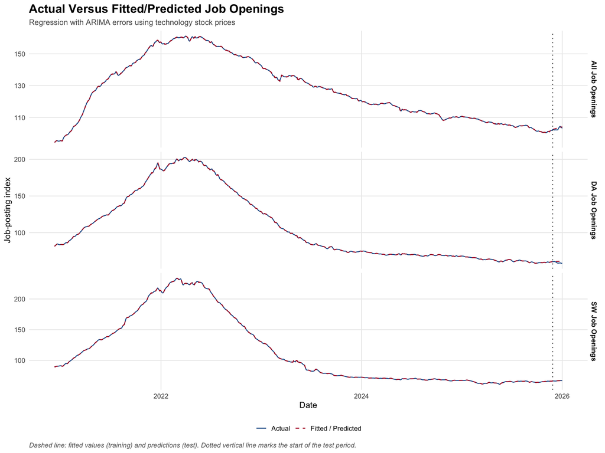

```r
fig <- plot_actual_vs_predicted(
  get_predictions("ARIMAX: Stock Prices"),
  title = "Actual Versus Fitted/Predicted Job Openings",
  subtitle = "Regression with ARIMA errors using technology stock prices",
  whole = TRUE
)
fig
```

```r
save_plot(fig, "ARIMAX_Stocks_whole_actual_vs_predicted.png", width = 12)
```

### 5.3.2 Job openings vs. Google Trends

**Test period**

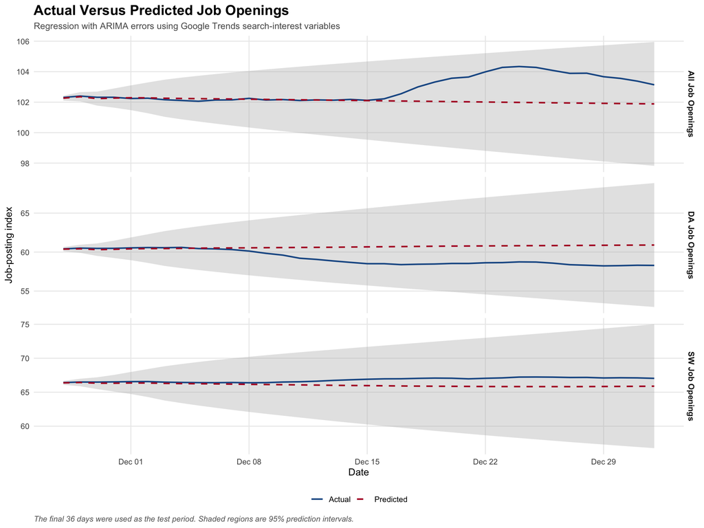

```r
fig <- plot_actual_vs_predicted(
  get_predictions("ARIMAX: Google Trends"),
  title = "Actual Versus Predicted Job Openings",
  subtitle = "Regression with ARIMA errors using Google Trends search-interest variables"
)
fig
```

```r
save_plot(fig, "ARIMAX_Google_Trends_test_actual_vs_predicted.png", width = 12)
```

**Whole series**

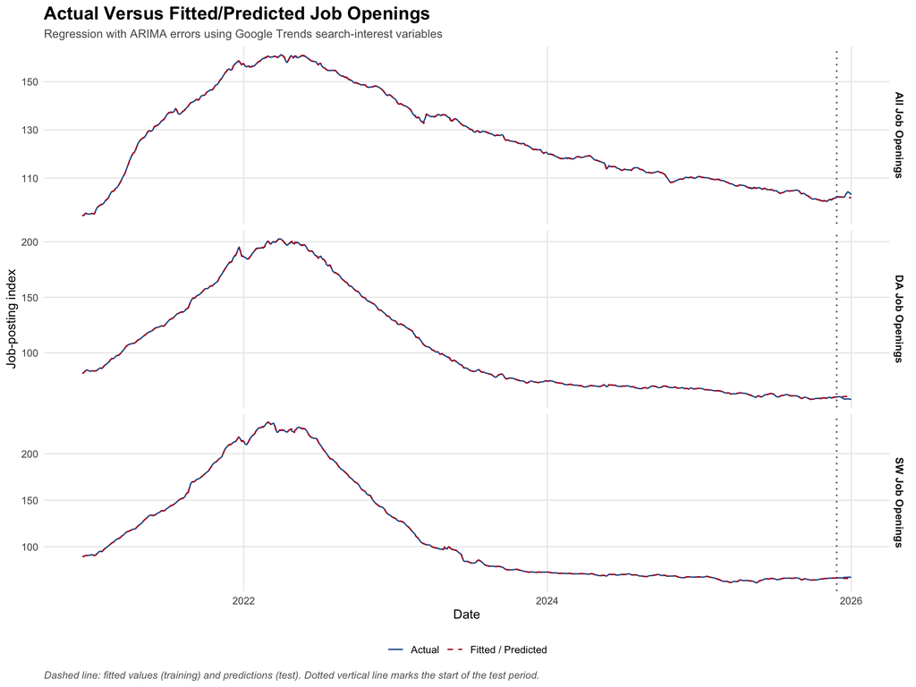

```r
fig <- plot_actual_vs_predicted(
  get_predictions("ARIMAX: Google Trends"),
  title = "Actual Versus Fitted/Predicted Job Openings",
  subtitle = "Regression with ARIMA errors using Google Trends search-interest variables",
  whole = TRUE
)
fig
```

```r
save_plot(fig, "ARIMAX_Google_Trends_whole_actual_vs_predicted.png", width = 12)
```

### 5.3.3 Job openings vs. CAPEX + PPI

**Test period**

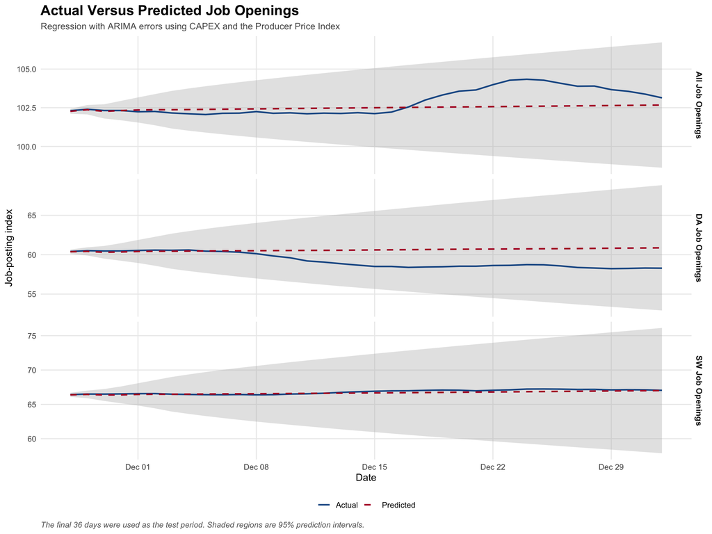

```r
fig <- plot_actual_vs_predicted(
  get_predictions("ARIMAX: CAPEX + PPI"),
  title = "Actual Versus Predicted Job Openings",
  subtitle = "Regression with ARIMA errors using CAPEX and the Producer Price Index"
)
fig
```

```r
save_plot(fig, "ARIMAX_CAPEX_PPI_test_actual_vs_predicted.png", width = 12)
```

**Whole series**

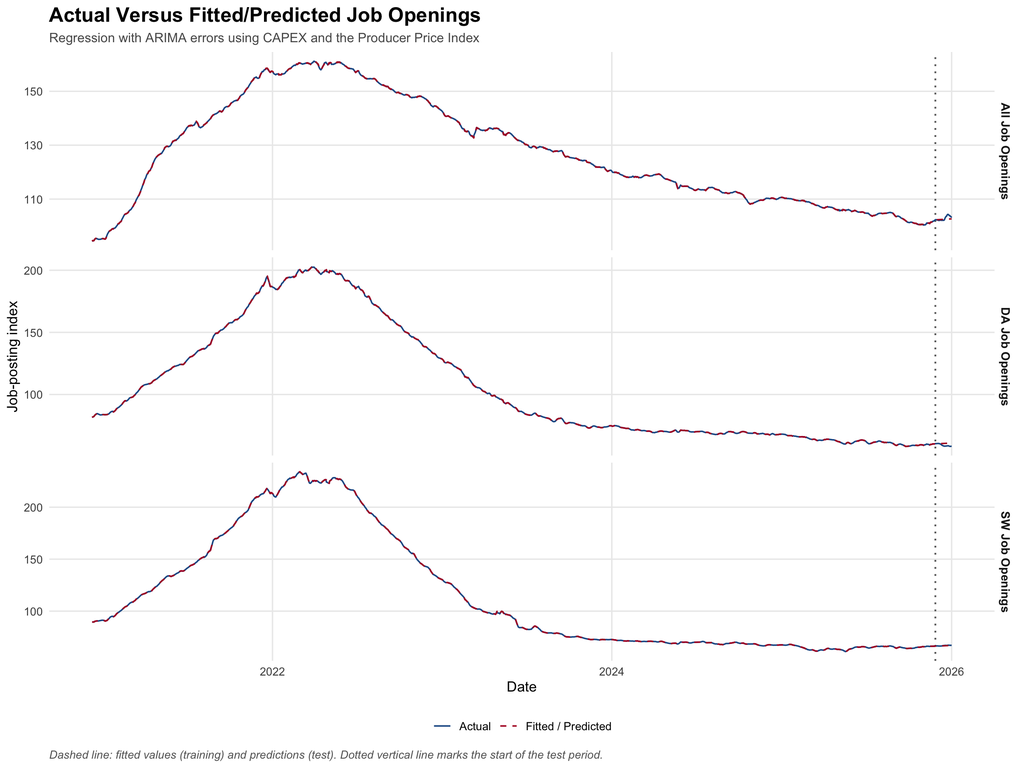

```r
fig <- plot_actual_vs_predicted(
  get_predictions("ARIMAX: CAPEX + PPI"),
  title = "Actual Versus Fitted/Predicted Job Openings",
  subtitle = "Regression with ARIMA errors using CAPEX and the Producer Price Index",
  whole = TRUE
)
fig
```

```r
save_plot(fig, "ARIMAX_CAPEX_PPI_whole_actual_vs_predicted.png", width = 12)
```

### 5.3.4 Selected models

```r
extract_model_description <- function(model) {
  output <- capture.output(print(model))
  trimws(output[grepl("Regression with ARIMA|ARIMA\\(", output)][1])
}

selected_models <- imap_dfr(forecast_runs, function(runs, set_name) {
  imap_dfr(runs, function(run, job_name) {
    tibble(
      Model          = set_name,
      Job_Openings   = job_labels[[job_name]],
      Selected_Model = extract_model_description(run$model),
      AICc           = run$model$aicc
    )
  })
}) %>%
  mutate(Job_Openings = factor(Job_Openings, levels = job_levels)) %>%
  arrange(factor(Model, levels = model_order), Job_Openings)

save_table(selected_models, "Selected_ARIMA_models.csv")

selected_models %>%
  kable(digits = 1, caption = "Models selected by auto.arima (training period)",
        col.names = c("Model", "Job Openings", "Selected Model", "AICc")) %>%
  kable_styling(full_width = FALSE, bootstrap_options = c("striped", "condensed")) %>%
  collapse_rows(columns = 1, valign = "top")
```

Models selected by auto.arima (training period)

| Model | Job Openings | Selected Model | AICc |
| --- | --- | --- | --- |
| ARIMA (baseline) | All Job Openings | ARIMA(1,2,1)(0,0,1)[7] | -3897.6 |
|  | DA Job Openings | ARIMA(0,2,1)(1,0,2)[7] | -1948.1 |
|  | SW Job Openings | ARIMA(0,2,2)(1,0,2)[7] | -1755.4 |
| ARIMAX: Stock Prices | All Job Openings | Regression with ARIMA(2,1,1)(2,0,0)[7] errors | -3554.9 |
|  | DA Job Openings | Regression with ARIMA(1,1,1)(2,0,0)[7] errors | -1660.2 |
|  | SW Job Openings | Regression with ARIMA(1,1,2)(2,0,0)[7] errors | -1398.1 |
| ARIMAX: Google Trends | All Job Openings | Regression with ARIMA(1,2,1)(0,0,1)[7] errors | -3893.7 |
|  | DA Job Openings | Regression with ARIMA(0,2,1)(1,0,2)[7] errors | -1944.1 |
|  | SW Job Openings | Regression with ARIMA(0,2,2)(1,0,2)[7] errors | -1751.8 |
| ARIMAX: CAPEX + PPI | All Job Openings | Regression with ARIMA(1,2,1)(0,0,1)[7] errors | -3895.8 |
|  | DA Job Openings | Regression with ARIMA(0,2,1)(1,0,2)[7] errors | -1944.6 |
|  | SW Job Openings | Regression with ARIMA(0,2,2)(1,0,2)[7] errors | -1752.0 |

**NoteFull model summaries (coefficients and training accuracy)**

```r
for (set_name in names(forecast_runs)) {
  for (job_name in names(forecast_runs[[set_name]])) {
    cat("\n==========", set_name, "->", job_labels[[job_name]], "==========\n")
    print(summary(forecast_runs[[set_name]][[job_name]]$model))
  }
}
```

```
========== ARIMA (baseline) -> DA Job Openings ==========
Series: y_train
ARIMA(0,2,1)(1,0,2)[7]

Coefficients:
          ma1     sar1    sma1     sma2
      -0.3954  -0.9221  0.0082  -0.8257
s.e.   0.0223   0.3248  0.3435   0.3146

sigma^2 = 0.01979:  log likelihood = 979.07
AIC=-1948.14   AICc=-1948.11   BIC=-1920.63

Training set error measures:
                       ME      RMSE        MAE        MPE      MAPE       MASE
Training set -0.001574771 0.1404369 0.09029139 0.00184703 0.0838401 0.06803859
                    ACF1
Training set 0.004377422

========== ARIMA (baseline) -> SW Job Openings ==========
Series: y_train
ARIMA(0,2,2)(1,0,2)[7]

Coefficients:
          ma1     ma2     sar1     sma1     sma2
      -0.3760  0.0548  -0.9014  -0.0330  -0.8077
s.e.   0.0236  0.0225   0.1487   0.1601   0.1487

sigma^2 = 0.02199:  log likelihood = 883.7
AIC=-1755.4   AICc=-1755.36   BIC=-1722.39

Training set error measures:
                       ME     RMSE       MAE         MPE       MAPE       MASE
Training set -0.001178859 0.147993 0.0860235 0.003327549 0.07427458 0.05603924
                    ACF1
Training set -0.00194627

========== ARIMA (baseline) -> All Job Openings ==========
Series: y_train
ARIMA(1,2,1)(0,0,1)[7]

```

[output cut: 199 more lines]

```
         ar1      ma1     sma1  all_capex_ppi_daily_interpolated_PCUAINFOAINFO
      0.1654  -0.5649  -0.9075                                         -0.3020
s.e.  0.0523   0.0437   0.0101                                          0.4261
      all_capex_ppi_daily_interpolated_capex
                                     -0.1858
s.e.                                  0.1347

sigma^2 = 0.006767:  log likelihood = 1953.9
AIC=-3895.81   AICc=-3895.76   BIC=-3862.79

Training set error measures:
                        ME       RMSE        MAE          MPE       MAPE
Training set -0.0007740796 0.08210323 0.05614325 0.0001843539 0.04408197
                   MASE        ACF1
Training set 0.08347322 -0.00374496
```

## 5.4 Model comparison

### 5.4.1 Test-period accuracy

```r
accuracy_table <- all_predictions %>%
  filter(Period == "Test") %>%
  group_by(Job_Type, Model) %>%
  summarise(
    RMSE = sqrt(mean((Actual - Fitted_Predicted)^2, na.rm = TRUE)),
    MAE  = mean(abs(Actual - Fitted_Predicted), na.rm = TRUE),
    MAPE = mean(if_else(Actual != 0, abs((Actual - Fitted_Predicted) / Actual), NA_real_),
                na.rm = TRUE) * 100,
    .groups = "drop"
  ) %>%
  group_by(Job_Type) %>%
  mutate(
    RMSE_vs_ARIMA = 100 * (RMSE / RMSE[Model == "ARIMA (baseline)"] - 1),
    Best          = RMSE == min(RMSE)
  ) %>%
  ungroup() %>%
  arrange(Job_Type, Model)

save_table(accuracy_table, "Test_accuracy_all_models.csv")

accuracy_table %>%
  select(-Best) %>%
  kable(digits = 3,
        col.names = c("Job Openings", "Model", "RMSE", "MAE", "MAPE (%)",
                      "RMSE change vs ARIMA (%)"),
        caption = paste0("Test-period accuracy (final ", test_horizon,
                         " days). Bold rows have the lowest RMSE for that job type.")) %>%
  kable_styling(full_width = FALSE, bootstrap_options = c("striped", "hover", "condensed")) %>%
  row_spec(which(accuracy_table$Best), bold = TRUE, background = "#FFF3B0") %>%
  collapse_rows(columns = 1, valign = "top")
```

Test-period accuracy (final 36 days). Bold rows have the lowest RMSE for that job type.

| Job Openings | Model | RMSE | MAE | MAPE (%) | RMSE change vs ARIMA (%) |
| --- | --- | --- | --- | --- | --- |
| All Job Openings | ARIMA (baseline) | 1.047 | 0.709 | 0.684 | 0.000 |
|  | Prophet (baseline) | 1.011 | 0.746 | 0.720 | -3.474 |
|  | ARIMAX: Stock Prices | 0.672 | 0.559 | 0.545 | -35.848 |
|  | ARIMAX: Google Trends | 1.173 | 0.782 | 0.753 | 12.041 |
|  | ARIMAX: CAPEX + PPI | 0.801 | 0.597 | 0.577 | -23.533 |
| DA Job Openings | ARIMA (baseline) | 1.493 | 1.229 | 2.096 | 0.000 |
|  | Prophet (baseline) | 2.449 | 2.091 | 3.560 | 64.038 |
|  | ARIMAX: Stock Prices | 1.912 | 1.556 | 2.655 | 28.071 |
|  | ARIMAX: Google Trends | 1.759 | 1.443 | 2.462 | 17.825 |
|  | ARIMAX: CAPEX + PPI | 1.710 | 1.401 | 2.390 | 14.538 |
| SW Job Openings | ARIMA (baseline) | 0.245 | 0.208 | 0.311 | 0.000 |
|  | Prophet (baseline) | 1.019 | 0.745 | 1.111 | 316.267 |
|  | ARIMAX: Stock Prices | 0.169 | 0.146 | 0.218 | -30.971 |
|  | ARIMAX: Google Trends | 0.906 | 0.758 | 1.131 | 269.873 |
|  | ARIMAX: CAPEX + PPI | 0.204 | 0.173 | 0.259 | -16.490 |

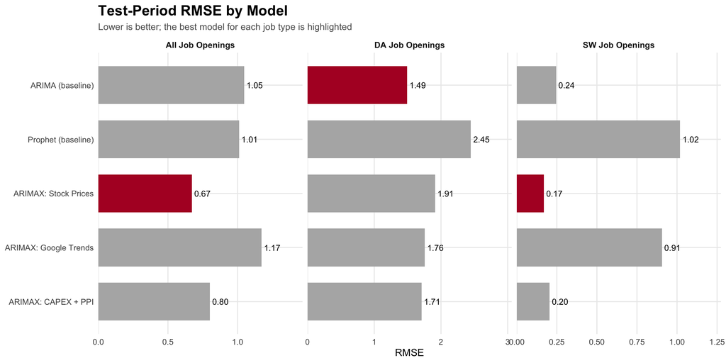

```r
fig_accuracy <- accuracy_table %>%
  mutate(Model = fct_rev(Model)) %>%
  ggplot(aes(RMSE, Model, fill = Best)) +
  geom_col(width = 0.7) +
  geom_text(aes(label = number(RMSE, accuracy = 0.01)), hjust = -0.15, size = 3.5) +
  facet_wrap(~ Job_Type, scales = "free_x") +
  scale_fill_manual(values = c(`TRUE` = col_pred, `FALSE` = "gray70"), guide = "none") +
  scale_x_continuous(expand = expansion(mult = c(0, 0.25))) +
  labs(title = "Test-Period RMSE by Model",
       subtitle = "Lower is better; the best model for each job type is highlighted",
       x = "RMSE", y = NULL) +
  theme_ts()

fig_accuracy
```

```r
save_plot(fig_accuracy, "Test_RMSE_by_model.png", width = 12, height = 6)
```

```r
best_models <- accuracy_table %>%
  filter(Best) %>%
  select(Job_Type, Best_Model = Model, RMSE, RMSE_vs_ARIMA)

best_models %>%
  kable(digits = 3, caption = "Best model for each job-opening series",
        col.names = c("Job Openings", "Best Model", "RMSE", "RMSE change vs ARIMA (%)")) %>%
  kable_styling(full_width = FALSE)
```

Best model for each job-opening series

| Job Openings | Best Model | RMSE | RMSE change vs ARIMA (%) |
| --- | --- | --- | --- |
| All Job Openings | ARIMAX: Stock Prices | 0.672 | -35.848 |
| DA Job Openings | ARIMA (baseline) | 1.493 | 0.000 |
| SW Job Openings | ARIMAX: Stock Prices | 0.169 | -30.971 |

### 5.4.2 Diebold–Mariano tests against the ARIMA baseline

The Diebold–Mariano (DM) test checks whether the squared-error loss of each external-predictor model differs significantly from the univariate ARIMA baseline over the test period. Because all test forecasts come from a single forecast origin (horizons 1 to 36), the test is used here as a descriptive guide rather than a formal multi-origin comparison.

```r
baseline_errors <- all_predictions %>%
  filter(Period == "Test", Model == "ARIMA (baseline)") %>%
  transmute(Date, Job_Type, Baseline_Error = Actual - Fitted_Predicted)

dm_results <- all_predictions %>%
  filter(Period == "Test", Model != "ARIMA (baseline)") %>%
  transmute(Date, Job_Type, Model, Model_Error = Actual - Fitted_Predicted) %>%
  inner_join(baseline_errors, by = c("Date", "Job_Type")) %>%
  group_by(Job_Type, Model) %>%
  summarise(
    {
      dm <- forecast::dm.test(Baseline_Error, Model_Error,
                              alternative = "two.sided", h = 1, power = 2)
      tibble(DM_Statistic = unname(dm$statistic), P_Value = dm$p.value)
    },
    Lower_Loss = if_else(mean(Model_Error^2) < mean(Baseline_Error^2),
                         as.character(first(Model)), "ARIMA (baseline)"),
    .groups = "drop"
  ) %>%
  mutate(Significant = if_else(P_Value < 0.05, "Yes", "No"))

save_table(dm_results, "Diebold_Mariano_vs_ARIMA.csv")

dm_results %>%
  kable(digits = 3,
        col.names = c("Job Openings", "Model", "DM Statistic", "p-value",
                      "Lower-Loss Model", "Significant (5%)"),
        caption = "Diebold–Mariano tests: each model versus the univariate ARIMA baseline") %>%
  kable_styling(full_width = FALSE, bootstrap_options = c("striped", "condensed")) %>%
  collapse_rows(columns = 1, valign = "top")
```

Diebold–Mariano tests: each model versus the univariate ARIMA baseline

| Job Openings | Model | DM Statistic | p-value | Lower-Loss Model | Significant (5%) |
| --- | --- | --- | --- | --- | --- |
| All Job Openings | Prophet (baseline) | 1.365 | 0.181 | Prophet (baseline) | No |
|  | ARIMAX: Stock Prices | 2.168 | 0.037 | ARIMAX: Stock Prices | Yes |
|  | ARIMAX: Google Trends | -4.696 | 0.000 | ARIMA (baseline) | Yes |
|  | ARIMAX: CAPEX + PPI | 4.223 | 0.000 | ARIMAX: CAPEX + PPI | Yes |
| DA Job Openings | Prophet (baseline) | -6.501 | 0.000 | ARIMA (baseline) | Yes |
|  | ARIMAX: Stock Prices | -6.993 | 0.000 | ARIMA (baseline) | Yes |
|  | ARIMAX: Google Trends | -6.772 | 0.000 | ARIMA (baseline) | Yes |
|  | ARIMAX: CAPEX + PPI | -6.391 | 0.000 | ARIMA (baseline) | Yes |
| SW Job Openings | Prophet (baseline) | -3.834 | 0.001 | ARIMA (baseline) | Yes |
|  | ARIMAX: Stock Prices | 3.407 | 0.002 | ARIMAX: Stock Prices | Yes |
|  | ARIMAX: Google Trends | -6.580 | 0.000 | ARIMA (baseline) | Yes |
|  | ARIMAX: CAPEX + PPI | 4.959 | 0.000 | ARIMAX: CAPEX + PPI | Yes |

# 6 Part 3 – Macroeconomic ARIMAX (Monthly)

**Model:** DA job openings regressed on the Federal Funds Rate, Personal Consumption Expenditures (PCE), and the Producer Price Index for the Information sector, with SARIMA errors. All series are aggregated to a common monthly frequency and a common time period.

## 6.1 Data

```r
fedfunds  <- read.csv(file.path(monthly_data_folder, "FEDFUNDS.csv"))
indeed_da <- read.csv(file.path(monthly_data_folder, "indeed_data_analysis_job_postings.csv"))
pce       <- read.csv(file.path(monthly_data_folder, "PCE.csv"))
ppi_info  <- read.csv(file.path(monthly_data_folder, "PPI_Information.csv"))

# Keep date and value columns
fedfunds <- fedfunds[, 1:2]; colnames(fedfunds) <- c("Date", "FedFundsRate")
pce      <- pce[, 1:2];      colnames(pce)      <- c("Date", "PCE")
ppi_info <- ppi_info[, 1:2]; colnames(ppi_info) <- c("Date", "PPIInformation")

fedfunds$Date <- as.Date(fedfunds$Date)
pce$Date      <- as.Date(pce$Date)
ppi_info$Date <- as.Date(ppi_info$Date)

indeed_da <- indeed_da %>%
  mutate(dateString = as.Date(dateString)) %>%
  filter(countryCode == "US", sectorName == "Data & Analytics", postingType == "TOTAL") %>%
  select(Date = dateString, DataAnalysisJobPostings = value)

# Convert any dataset to monthly averages
to_monthly <- function(df) {
  df %>%
    mutate(Date = floor_date(Date, unit = "month")) %>%
    group_by(Date) %>%
    summarise(across(where(is.numeric), ~ mean(.x, na.rm = TRUE)), .groups = "drop")
}

merged_data <- Reduce(
  function(x, y) merge(x, y, by = "Date", all = FALSE),
  list(to_monthly(indeed_da), to_monthly(fedfunds), to_monthly(pce), to_monthly(ppi_info))
) %>%
  arrange(Date) %>%
  filter(if_all(-Date, ~ !is.na(.x)))

df <- merged_data

start_year  <- year(min(df$Date))
start_month <- month(min(df$Date))

df.ts <- ts(df[, -1], start = c(start_year, start_month), frequency = 12)

monthly_variables <- c(
  DataAnalysisJobPostings = "Data Analysis Job Postings",
  FedFundsRate            = "Federal Funds Rate",
  PCE                     = "PCE",
  PPIInformation          = "PPI Information"
)

cat("Common monthly period:", format(min(df$Date)), "to", format(max(df$Date)),
    "|", nrow(df), "monthly observations\n")
```

```
Common monthly period: 2020-02-01 to 2026-05-01 | 76 monthly observations
```

```r
kable(head(df), digits = 2,
      caption = "Merged monthly dataset: DA job postings, Fed Funds Rate, PCE, and PPI (Information)") %>%
  kable_styling(full_width = FALSE)
```

Merged monthly dataset: DA job postings, Fed Funds Rate, PCE, and PPI (Information)

| Date | DataAnalysisJobPostings | FedFundsRate | PCE | PPIInformation |
| --- | --- | --- | --- | --- |
| 2020-02-01 | 99.84 | 1.58 | 14828.1 | 104.3 |
| 2020-03-01 | 96.43 | 0.65 | 13812.8 | 104.6 |
| 2020-04-01 | 69.63 | 0.05 | 12249.2 | 104.5 |
| 2020-05-01 | 57.72 | 0.05 | 13281.5 | 103.8 |
| 2020-06-01 | 56.88 | 0.08 | 14049.2 | 103.8 |
| 2020-07-01 | 60.37 | 0.09 | 14307.2 | 104.1 |

## 6.2 Exploratory analysis

### 6.2.1 Time-series plots

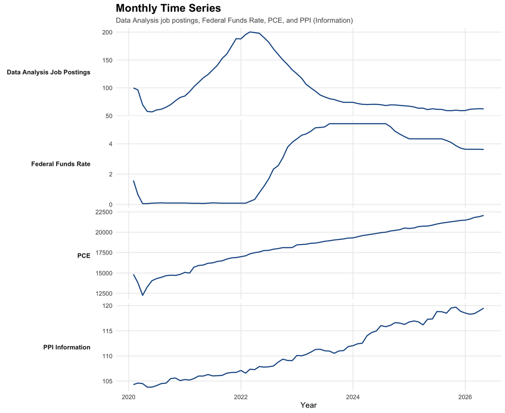

```r
monthly_long <- df %>%
  pivot_longer(-Date, names_to = "Variable", values_to = "Value") %>%
  mutate(Variable = factor(monthly_variables[Variable], levels = monthly_variables))

fig_monthly <- ggplot(monthly_long, aes(Date, Value)) +
  geom_line(linewidth = 0.8, color = col_actual) +
  facet_grid(Variable ~ ., scales = "free_y", switch = "y") +
  labs(title = "Monthly Time Series",
       subtitle = "Data Analysis job postings, Federal Funds Rate, PCE, and PPI (Information)",
       x = "Year", y = NULL) +
  theme_ts() +
  theme(strip.placement = "outside",
        strip.text.y.left = element_text(angle = 0, hjust = 1))

fig_monthly
```

```r
save_plot(fig_monthly, "Monthly_time_series.png", width = 11, height = 9)
```

### 6.2.2 Lag plots

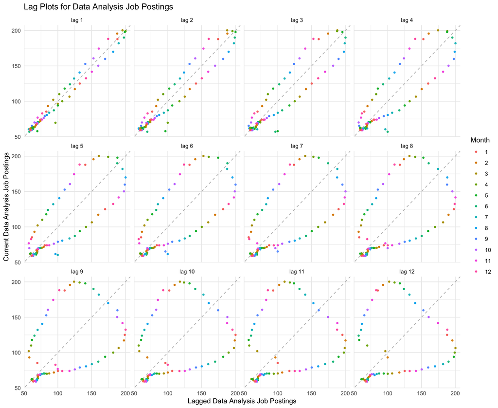

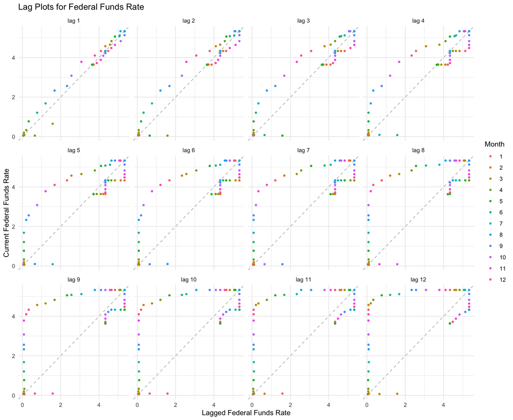

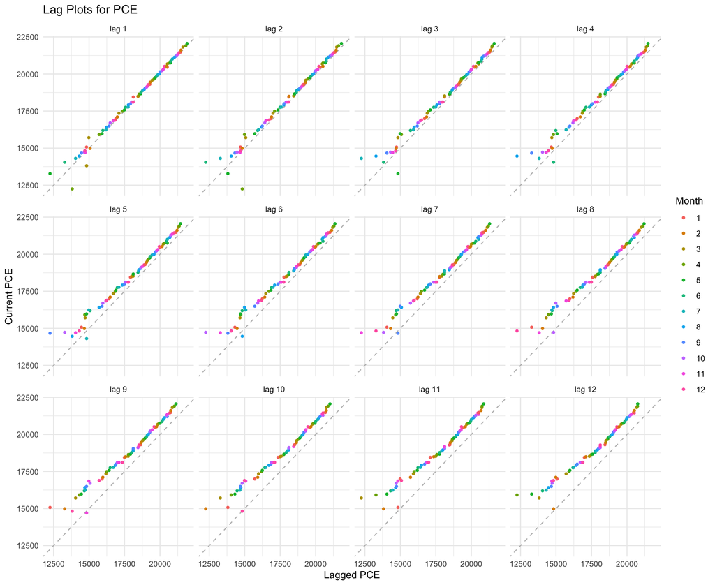

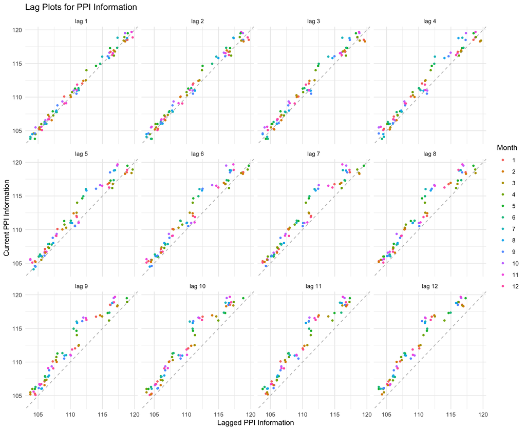

```r
for (var_name in names(monthly_variables)) {
  p <- gglagplot(df.ts[, var_name], do.lines = FALSE, lags = 12) +
    ggtitle(paste("Lag Plots for", monthly_variables[[var_name]])) +
    xlab(paste("Lagged", monthly_variables[[var_name]])) +
    ylab(paste("Current", monthly_variables[[var_name]])) +
    theme_minimal()
  print(p)
}
```

### 6.2.3 ACF plots

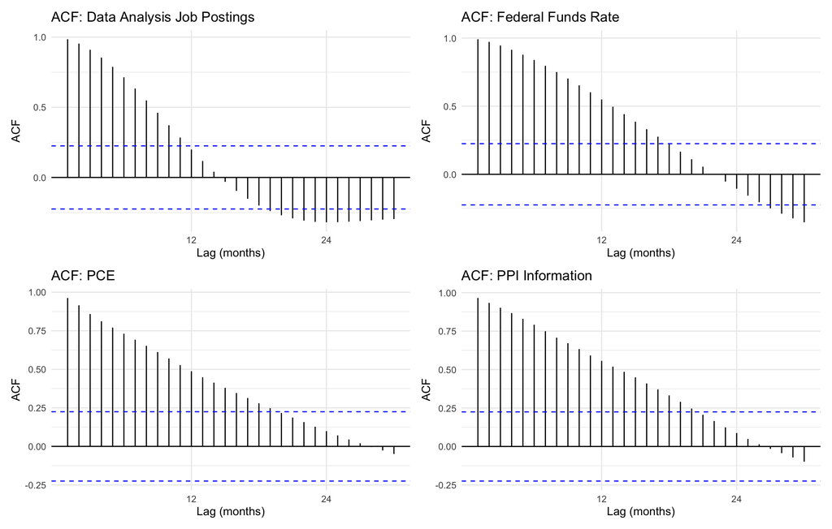

```r
acf_plots <- lapply(names(monthly_variables), function(var_name) {
  ggAcf(df.ts[, var_name], lag.max = 30) +
    ggtitle(paste("ACF:", monthly_variables[[var_name]])) +
    xlab("Lag (months)") +
    theme_minimal()
})

wrap_plots(acf_plots, ncol = 2)
```

### 6.2.4 Stationarity (Augmented Dickey–Fuller test)

```r
adf_results <- map_dfr(names(monthly_variables), function(var_name) {
  adf_result <- adf.test(df.ts[, var_name])
  tibble(
    Variable      = monthly_variables[[var_name]],
    ADF_Statistic = as.numeric(adf_result$statistic),
    Lag_Order     = as.numeric(adf_result$parameter),
    P_Value       = adf_result$p.value,
    Conclusion    = if_else(adf_result$p.value < 0.05, "Stationary", "Non-stationary")
  )
})

kable(adf_results, digits = 4, caption = "ADF test results for monthly variables") %>%
  kable_styling(full_width = FALSE, bootstrap_options = c("striped", "hover", "condensed"))
```

ADF test results for monthly variables

| Variable | ADF_Statistic | Lag_Order | P_Value | Conclusion |
| --- | --- | --- | --- | --- |
| Data Analysis Job Postings | -4.5443 | 4 | 0.0100 | Stationary |
| Federal Funds Rate | -1.8527 | 4 | 0.6356 | Non-stationary |
| PCE | -2.8296 | 4 | 0.2369 | Non-stationary |
| PPI Information | -2.2205 | 4 | 0.4855 | Non-stationary |

If p-value < 0.05 → reject the unit root → stationary; if p-value ≥ 0.05 → fail to reject → non-stationary.

## 6.3 Fitting the ARIMAX model with `auto.arima()`

```r
y    <- df.ts[, "DataAnalysisJobPostings"]
xreg <- df.ts[, c("FedFundsRate", "PCE", "PPIInformation")]

fit_auto <- auto.arima(y, xreg = xreg)
summary(fit_auto)
```

```
Series: y
Regression with ARIMA(2,0,3)(1,0,0)[12] errors

Coefficients:
         ar1      ar2      ma1      ma2     ma3    sar1  FedFundsRate     PCE
      1.9038  -0.9261  -0.3054  -0.3652  0.4241  0.3382       -6.2969  0.0063
s.e.  0.0612   0.0611   0.1463   0.1370  0.1580  0.1623        3.7001  0.0014
      PPIInformation
              0.0008
s.e.          0.2575

sigma^2 = 13.63:  log likelihood = -206.54
AIC=433.07   AICc=436.46   BIC=456.38

Training set error measures:
                     ME     RMSE      MAE        MPE     MAPE       MASE
Training set -0.1122304 3.466978 2.459962 -0.3069704 2.921699 0.05593549
                   ACF1
Training set 0.06480216
```

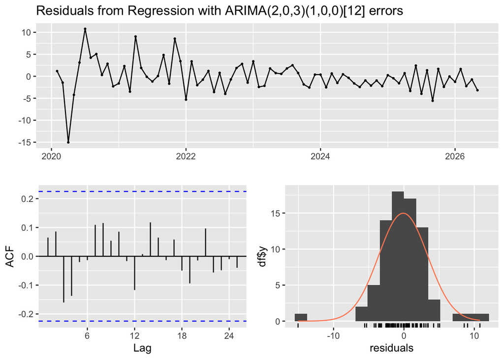

```
    Ljung-Box test

data:  Residuals from Regression with ARIMA(2,0,3)(1,0,0)[12] errors
Q* = 10.727, df = 9, p-value = 0.2949

Model df: 6.   Total lags used: 15
```

```r
checkresiduals(fit_auto)
```

## 6.4 Fitting the model manually

### 6.4.1 Step 1: Regression

We first fit a linear regression of DA job postings on the three macroeconomic indicators and then model the regression residuals as a (S)ARIMA process.

```r
reg_model <- lm(DataAnalysisJobPostings ~ FedFundsRate + PCE + PPIInformation, data = df)
summary(reg_model)
```

```
Call:
lm(formula = DataAnalysisJobPostings ~ FedFundsRate + PCE + PPIInformation,
    data = df)

Residuals:
    Min      1Q  Median      3Q     Max
-40.247 -19.529  -0.008  18.283  66.464

Coefficients:
                 Estimate Std. Error t value Pr(>|t|)
(Intercept)     1.536e+03  1.309e+02  11.735  < 2e-16 ***
FedFundsRate   -1.314e+01  2.075e+00  -6.332 1.84e-08 ***
PCE             4.337e-02  3.892e-03  11.145  < 2e-16 ***
PPIInformation -1.975e+01  1.712e+00 -11.536  < 2e-16 ***
---
Signif. codes:  0 '***' 0.001 '**' 0.01 '*' 0.05 '.' 0.1 ' ' 1

Residual standard error: 23.29 on 72 degrees of freedom
Multiple R-squared:  0.7376,    Adjusted R-squared:  0.7266
F-statistic: 67.46 on 3 and 72 DF,  p-value: < 2.2e-16
```

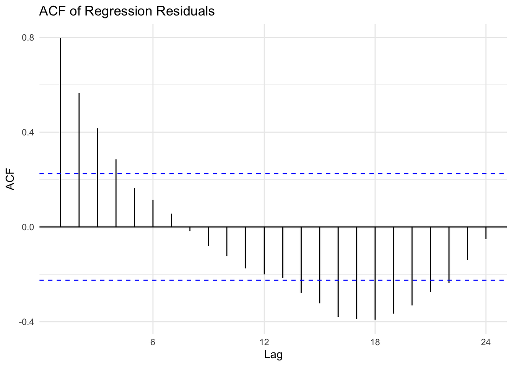

```r
res.fit <- ts(residuals(reg_model), start = c(start_year, start_month), frequency = 12)

ggAcf(res.fit) + ggtitle("ACF of Regression Residuals") + theme_minimal()
```

```r
# Check: automatic order selection for the residuals
auto.arima(res.fit)
```

```
Series: res.fit
ARIMA(1,0,1) with zero mean

Coefficients:
         ar1     ma1
      0.6975  0.2939
s.e.  0.0987  0.1363

sigma^2 = 178:  log likelihood = -304.31
AIC=614.61   AICc=614.95   BIC=621.6
```

### 6.4.2 Step 2: Identify the error model

#### 6.4.2.1 First-order differencing

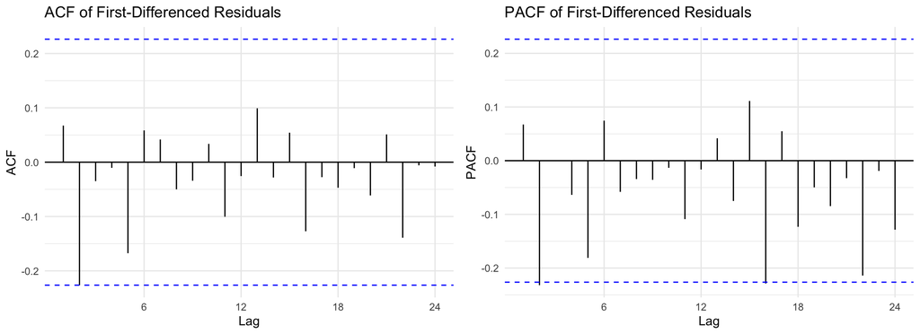

```r
first_diff <- diff(res.fit)

grid.arrange(
  ggAcf(first_diff)  + ggtitle("ACF of First-Differenced Residuals")  + theme_minimal(),
  ggPacf(first_diff) + ggtitle("PACF of First-Differenced Residuals") + theme_minimal(),
  ncol = 2
)
```

No additional ordinary differencing appears necessary, so $d = 0$ is a candidate (with $d = 1$ also considered).